# homework

```r
library(SA25204152)    # 加载你自己的包
library(ggplot2)       # 报错的元凶，必须加！
library(knitr)
library(gridExtra)     # 你用了 grid.arrange
library(microbenchmark)# 你用了 microbenchmark
library(rbenchmark)    # 你用了 benchmark
library(boot)          # 你用了 boot
library(bootstrap)     # 你用了 bootstrap
library(DAAG)          # 你用了 DAAG
library(lpSolve)       # 你用了 lpSolve
```

# HW0

## Question

Use knitr to produce at at least 3 examples where text is mixed with figures, tables and mathematical formulas.

## Answer

### Example 1: 体重与身高的线性回归

#### 1.1 问题

研究成年人体重与身高之间的关系，建立线性回归模型预测体重。

身高体重数据集（前10行）

| 身高 | 体重 |
| --- | --- |
| 183.71 | 104.53 |
| 164.35 | 82.77 |
| 173.63 | 89.35 |
| 176.33 | 90.46 |
| 174.04 | 83.26 |
| 168.94 | 88.21 |
| 185.12 | 97.01 |
| 169.05 | 84.33 |
| 190.18 | 106.81 |
| 169.37 | 89.61 |

#### 1.2 答案

##### 1.2.1模型

线性回归模型的数学表达式为：

$$\text{体重}=\beta_0+\beta_1\times\text{身高}+\epsilon$$
其$\beta_0$是截距，$\beta_1$是斜率，$\epsilon$是随机误差项。

###### 1.2.2 结果分析

线性回归模型系数

| 系数 | 估计值 | 标准误 | t值 | p值 |
| --- | --- | --- | --- | --- |
| (Intercept) | -58.7408 | 8.2033 | -7.1606 | 3.89e-10 |
| 身高 | 0.8483 | 0.0481 | 17.6347 | 6.11e-29 |

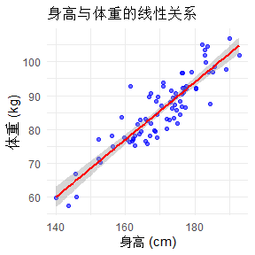

### Example 2: 广告支出与销售额对数回归

#### 2.1 问题

研究公司广告支出与销售额的关系，考虑非线性增长模式。

广告支出与销售额数据（前10行）

| 广告支出 | 销售额 |
| --- | --- |
| 211.15 | 128.52 |
| 60.34 | 30.36 |
| 373.11 | 547.25 |
| 245.24 | 210.58 |
| 495.35 | 2205.62 |
| 499.78 | 2236.12 |
| 25.91 | 30.38 |
| 382.50 | 778.57 |
| 341.79 | 713.87 |
| 488.63 | 3055.94 |

#### 2.2 答案

##### 2.2.1模型

对数线性回归模型：

$$\ln(\text{销售额})=\beta_0+\beta_1\times\text{广告支出}+\epsilon$$

###### 2.2.2 结果分析

对数回归模型系数

|  | Estimate | Std. Error | t value | Pr(>\|t\|) |
| --- | --- | --- | --- | --- |
| (Intercept) | 3.117161 | 0.097098 | 32.10332 | 0 |
| 广告支出 | 0.009666 | 0.000307 | 31.43886 | 0 |

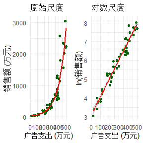

### Example 3: 温度与植物生长的二次回归

#### 3.1 问题

研究温度对植物生长速率的影响，考虑存在最适温度的情况。

温度与植物生长速率数据（前10行）

| 温度 | 生长速率 |
| --- | --- |
| 15.19 | 2.64 |
| 30.11 | 6.85 |
| 35.18 | 2.73 |
| 38.25 | 0.00 |
| 30.86 | 7.18 |
| 21.01 | 7.21 |
| 34.80 | 2.67 |
| 34.63 | 2.66 |
| 24.86 | 7.71 |
| 20.99 | 8.08 |

#### 3.2 答案

##### 3.2.1模型

模型公式：

$$\text{生长速率}=\beta_0+\beta_1\times\text{温度}+\beta_2\times\text{温度}^2+\epsilon$$

###### 3.2.2 结果分析

二次回归模型系数

|  | Estimate | Std. Error | t value | Pr(>\|t\|) |
| --- | --- | --- | --- | --- |
| (Intercept) | -9.1716 | 0.9377 | -9.7813 | 0 |
| poly(温度, 2, raw = TRUE)1 | 1.3373 | 0.0923 | 14.4876 | 0 |
| poly(温度, 2, raw = TRUE)2 | -0.0282 | 0.0020 | -14.4729 | 0 |

温度效应分析结果

|  | 指标 | 数值 |
| --- | --- | --- |
| poly(温度, 2, raw = TRUE)1 | 最适温度 | 23.693 |
| (Intercept) | 最大生长速率 | 6.671 |
| poly(温度, 2, raw = TRUE)2 | 二次项系数 | -0.028 |
|  | 拟合优度R² | 0.760 |

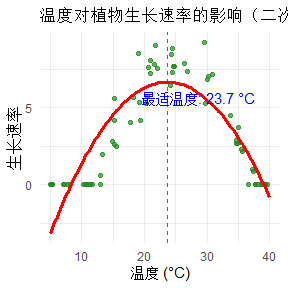

# HW1

## Question

The Rayleigh density [162, Ch. 18] is $f(x) = \frac{x}{\sigma^2} e^{-x^2 / (2\sigma^2)}, \quad x \ge 0, \sigma > 0.$Develop an algorithm to generate random samples from a Rayleigh(σ) distribution. Generate Rayleigh(σ) samples for several choices of σ > 0 and check that the mode of the generated samples is close to the theoretical mode σ (check the histogram).

## Answer 3.4

### 逆变换算法

Rayleigh($\sigma$) distribution 的分布函数能表示成
$$F(x) = \int_{0}^{x}
\frac{t}{\sigma^2} e^{-t^{2}/ (2 \sigma^{2})} dt=1-e^{-x^2/(2\sigma^2)}$$

利用逆变换采样法，令U=F(X)，则U是均匀分布(0,1)的随机变量。设$u=F(x)$可以得到$x=\sqrt{-2\sigma^2ln(1-u)}$

则要生成一个服从参数为$\sigma$的Rayleigh($\sigma$) distribution的随机样本x，我们只需要：

1.从Uniform(0,1) 分布中生成一个随机数u

2.利用以下公式计算x：$x=\sigma \sqrt{-2ln(u)}$

### 模拟实验和验证

生成参数为不同$\sigma$的样本，并利用直方图验证样本的众数和理论众数。

[figure not shown]

## Question

A discrete random variable X has probability mass function

| $x$ | 0 | 1 | 2 | 3 | 4 |
| --- | --- | --- | --- | --- | --- |
| $p(x)$ | 0.1 | 0.2 | 0.2 | 0.2 | 0.3 |

## Answer 3.5

由题目可知该离散随机变量X的分布函数可能取值为：F(0)=0.1,F(1)=0.3,F(2)=0.5,F(3)=0.7,F(4)=1.0,则逆变换的算法为：

1.生成随机数U

2，若$F(x_{i-1})\leq u < F(x_{i})$,则X=$x_i$。

根据该算法得到1000个样本并创建相对频率表，比较相对频率与理论频率。

```
#> [1] "--- 使用逆变换法生成样本的结果 ---"
#>   Value Theoretical_Prob Empirical_Freq Empirical_Relative_Freq
#> 1     0              0.1             96                   0.096
#> 2     1              0.2            167                   0.167
#> 3     2              0.2            202                   0.202
#> 4     3              0.2            208                   0.208
#> 5     4              0.3            327                   0.327
```

使用R sample函数抽样结果：

```
#> [1] "--- 使用 R 内置的 sample() 函数生成样本的结果 ---"
#>   Value Theoretical_Prob Empirical_Freq Empirical_Relative_Freq
#> 1     0              0.1             99                   0.099
#> 2     1              0.2            213                   0.213
#> 3     2              0.2            192                   0.192
#> 4     3              0.2            192                   0.192
#> 5     4              0.3            304                   0.304
```

## Question

Write a function to generate a random sample of size n from the Beta(a, b) distribution by the acceptance-rejection method. Generate a random sample of size 1000 from the Beta(3,2) distribution. Graph the histogram of the sample with the theoretical Beta(3,2) density superimposed.

## Answer 3.7

由于Beta分布的支撑集是[0,1],我们令提议分布为标准均匀分布，其密度函数为$g(x)=1$,则我们寻找的常数M为Beta(3,2)分布的概率密度函数的最大值。

### 接受拒绝函数

对应接受拒绝函数为以下所示

```r
beta_rejection_sampler <- function(n, a, b) {
  # 计算常数 M，即目标分布 f(x) 的最大值。
  # 对于 a>1, b>1 的 Beta 分布，其众数（峰值点）在 (a-1)/(a+b-2)
  # 如果 a<=1 或 b<=1，峰值可能在 0 或 1，或者函数是单调的。
  # 为了通用性，我们可以使用 optimize 函数寻找 f(x) 在 [0, 1] 上的最大值。
  # dbeta 是 R 中 Beta 分布的密度函数。
  m_optim <- optimize(f = function(x) dbeta(x, a, b),
                      interval = c(0, 1),
                      maximum = TRUE)
  M <- m_optim$objective # 提取找到的最大值

  # 初始化一个用于存放结果的空向量
  samples <- numeric(n)
  count <- 0 # 记录已接受的样本数

  while (count < n) {
    # 步骤 1: 从提议分布 g(x) = U(0, 1) 中抽取一个候选样本
    candidate <- runif(1)

    # 步骤 2: 从 U(0, 1) 中抽取一个随机数 u，用于决定是否接受
    u <- runif(1)

    # 步骤 3: 计算接受概率 f(candidate) / (M * g(candidate))
    # 因为 g(x) = 1, 所以这简化为 f(candidate) / M
    acceptance_prob <- dbeta(candidate, a, b) / M

    # 步骤 4: 如果 u 小于等于接受概率，则接受该候选样本
    if (u <= acceptance_prob) {
      count <- count + 1
      samples[count] <- candidate
    }
  }

  return(samples)
}
```

### 生成Beta(3,2)的样本

```r
# 设置随机种子以保证结果可复现
set.seed(123)

# 定义参数
sample_size <- 1000
shape_a <- 3
shape_b <- 2

# 生成样本
beta_samples <- beta_rejection_sampler(n = sample_size, a = shape_a, b = shape_b)

# 查看前几个样本
print(head(beta_samples))
```

```
#> [1] 0.9404673 0.5514350 0.6775706 0.2460877 0.6405068 0.6557058
```

### 创建直方图并叠加理论密度曲线

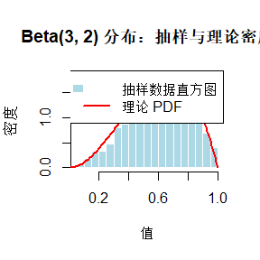

```r
# 绘制直方图
# freq = FALSE 表示纵轴显示密度而非频数，这样才能与密度曲线进行比较
hist(beta_samples,
     freq = FALSE,
     breaks = 30,  # 增加条柱数量以获得更平滑的形状
     main = "Beta(3, 2) 分布：抽样与理论密度",
     xlab = "值",
     ylab = "密度",
     col = "lightblue",
     border = "white")

# 叠加理论 Beta(3, 2) 密度曲线
# add = TRUE 表示将曲线添加到现有图形上
# lwd = 2 设置线条宽度，col = "red" 设置线条颜色
curve(dbeta(x, shape1 = shape_a, shape2 = shape_b),
      from = 0,
      to = 1,
      add = TRUE,
      col = "red",
      lwd = 2)

# 添加图例
legend("topright",
       legend = c("抽样数据直方图", "理论 PDF"),
       fill = c("lightblue", NA),
       border = c("white", NA),
       lty = c(NA, 1),
       lwd = c(NA, 2),
       col = c("black", "red"))
```

## Question

Generate a random sample of size 1000 from a normal location mixture. The components of the mixture have N(0, 1) and N(3, 1) distributions with mixing probabilities p1 and p2 = 1 − p1. Graph the histogram of the sample with density superimposed, for p1 = 0.75. Repeat with different values for p1 and observe whether the empirical distribution of the mixture appears to be bimodal. Make a conjecture about the values of p1 that produce bimodal mixtures.

## Answer 3.11

混合分布的概率密度函数$f(x)=p_1 \cdot \phi(x;\mu_1=0,\sigma_1=1)+p_2 \cdot \phi(x;\mu_2=3,\sigma_2=1)$,其中$\phi(x;\mu,\sigma)$是正态分布的密度函数，且$p_2=1-p_1$

### $p_1$=0.75时生成样本并绘图

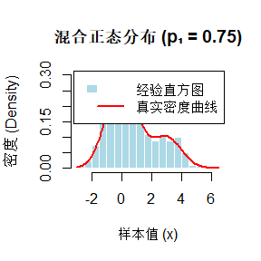

```r
# --- 参数设置 ---
n <- 1000       # 样本量
p1 <- 0.75      # 第一个正态分布 N(0, 1) 的混合概率
mu1 <- 0        # 第一个分布的均值
sigma1 <- 1     # 第一个分布的标准差
mu2 <- 3        # 第二个分布的均值
sigma2 <- 1     # 第二个分布的标准差

# --- 生成混合样本 ---
# 为了让结果可重复，我们设置一个随机种子
set.seed(123)

# 第一步：根据概率 p1 和 p2 (1-p1) 决定1000个样本点分别来自哪个分布
# sample() 函数会生成一个包含1和2的向量，其中1的比例约等于p1
component_choice <- sample(c(1, 2), size = n, replace = TRUE, prob = c(p1, 1 - p1))

# 第二步：根据上面的选择，从对应的正态分布中生成随机数
x_sample <- numeric(n)
n1 <- sum(component_choice == 1) # 来自 N(0, 1) 的样本数
n2 <- n - n1                     # 来自 N(3, 1) 的样本数

x_sample[component_choice == 1] <- rnorm(n1, mean = mu1, sd = sigma1)
x_sample[component_choice == 2] <- rnorm(n2, mean = mu2, sd = sigma2)

# --- 定义真实的混合密度函数 ---
mixture_pdf <- function(x, p, mu1, sigma1, mu2, sigma2) {
  return(p * dnorm(x, mean = mu1, sd = sigma1) + (1 - p) * dnorm(x, mean = mu2, sd = sigma2))
}

# --- 绘制图形 ---
# 绘制频率直方图 (freq = FALSE 表示纵轴为密度)
hist(x_sample, breaks = 30, freq = FALSE,
     main = "混合正态分布 (p₁ = 0.75)",
     xlab = "样本值 (x)",
     ylab = "密度 (Density)",
     col = "lightblue",
     border = "white")

# 叠加真实的密度曲线
curve(mixture_pdf(x, p = p1, mu1, sigma1, mu2, sigma2),
      add = TRUE,
      col = "red",
      lwd = 2) # lwd 控制线条宽度

# 添加图例
legend("topright",
       legend = c("经验直方图", "真实密度曲线"),
       fill = c("lightblue", NA),
       border = c("white", NA),
       lty = c(NA, 1),
       lwd = c(NA, 2),
       col = c("black", "red"))
```

### 探究不同$p_1$值对分布形态的影响

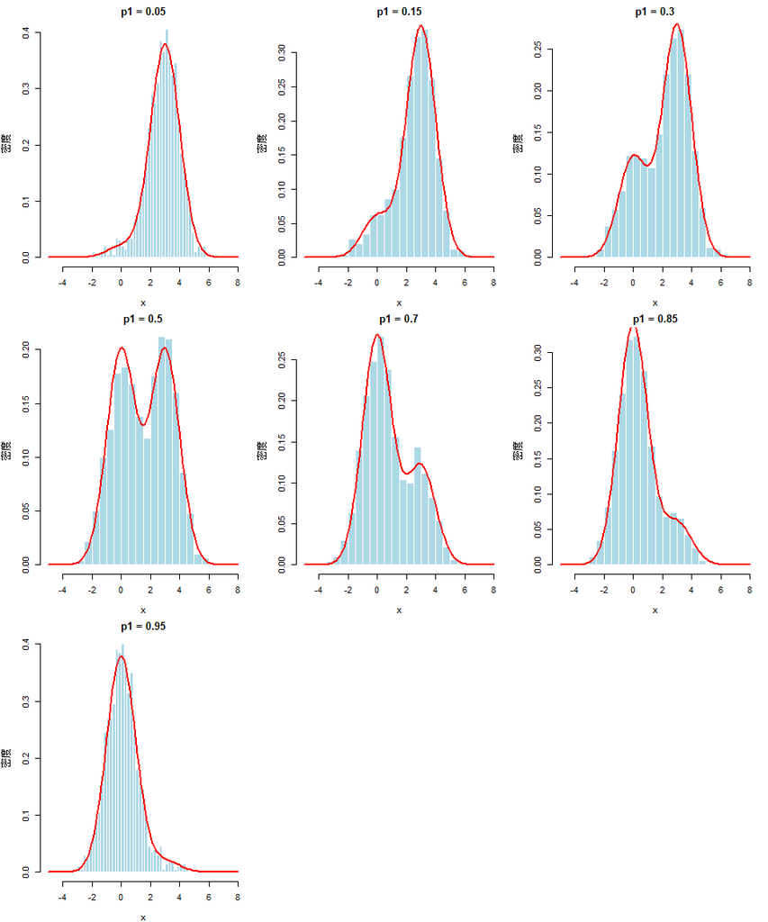

```r
# --- 创建一个函数用于生成和绘制图形 ---
generate_mixture_plot <- function(p1_val, n = 1000, mu1 = 0, sigma1 = 1, mu2 = 3, sigma2 = 1) {

  # 设置随机种子以保证结果可复现
  set.seed(42)

  # 生成混合样本
  component_choice <- sample(c(1, 2), size = n, replace = TRUE, prob = c(p1_val, 1 - p1_val))
  x_sample <- numeric(n)
  x_sample[component_choice == 1] <- rnorm(sum(component_choice == 1), mean = mu1, sd = sigma1)
  x_sample[component_choice == 2] <- rnorm(sum(component_choice == 2), mean = mu2, sd = sigma2)

  # 定义混合密度函数
  mixture_pdf <- function(x) {
    p1_val * dnorm(x, mean = mu1, sd = sigma1) + (1 - p1_val) * dnorm(x, mean = mu2, sd = sigma2)
  }

  # 绘制直方图和密度曲线
  hist(x_sample, breaks = 30, freq = FALSE,
       main = paste("p1 =", p1_val),
       xlab = "x",
       ylab = "密度",
       xlim = c(-5, 8), # 固定x轴范围以便于比较
       col = "lightblue",
       border = "white")

  curve(mixture_pdf, add = TRUE, col = "red", lwd = 2)
}

# --- 设定一组 p1 值进行测试 ---
p1_values <- c(0.05, 0.15, 0.3, 0.5, 0.7, 0.85, 0.95)

# --- 设置绘图区域布局，例如3行3列 ---
par(mfrow = c(3, 3), mar = c(4, 4, 2, 1))

# --- 循环生成每个 p1 值的图像 ---
for (p in p1_values) {
  generate_mixture_plot(p)
}

# --- 恢复默认的绘图布局 ---
par(mfrow = c(1, 1))
```

## Question

Simulate a continuous Exponential-Gamma mixture. Suppose that the rate parameter Λ has Gamma(r, β) distribution and Y has Exp(Λ) distribution. That is, (Y |Λ = λ) ∼ fY (y|λ) = λe−λy. Generate 1000 random observations from this mixture with r = 4 and β = 2.

## Answer3.12

构建Exponential-Gamma Mixture主要分为两步：

1.生成参数$\Lambda$,$\Lambda$服从Gamma(4,2),从Gamma分布中生成1000个随机样本$\Lambda$。

2.对于生一步生成的每个$\Lambda_i(i=1,2,\dots,1000)$我们都从对应指数分布Exp($\Lambda_i$)中生成一个随机样本$y_i$

```r
# 设定参数
n <- 1000  # 需要生成的观测数量
r <- 4     # Gamma分布的形状参数 (shape)
beta <- 2  # Gamma分布的率参数 (rate)

# 为了让每次运行的结果都一样，设定一个随机种子
set.seed(123)

# 步骤 1: 从Gamma分布生成1000个率参数 lambda
# R的rgamma函数中，shape参数对应r，rate参数对应beta
lambda_samples <- rgamma(n, shape = r, rate = beta)

# 查看前几个生成的率参数
print("生成的前6个率参数 (lambda):")
```

```
#> [1] "生成的前6个率参数 (lambda):"
```

```r
print(head(lambda_samples))
```

```
#> [1] 1.2649897 3.0404103 0.5263902 1.8730270 3.7219774 2.2077031
```

```r
# 步骤 2: 对于每一个生成的lambda，从对应的指数分布中生成Y
# R的rexp函数是向量化的，可以直接将lambda_samples向量作为rate参数传入
y_samples <- rexp(n, rate = lambda_samples)

# 查看最终生成的前几个观测值
print("最终生成的前6个观测值 (Y):")
```

```
#> [1] "最终生成的前6个观测值 (Y):"
```

```r
print(head(y_samples))
```

```
#> [1] 1.10894967 1.15686173 7.13358651 0.54195852 0.25173776 0.08799354
```

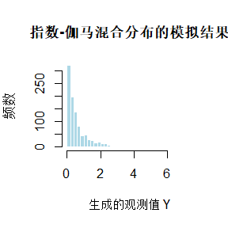

```r
# (可选) 绘制结果的直方图以可视化其分布
hist(y_samples,
     breaks = 50,
     main = "指数-伽马混合分布的模拟结果",
     xlab = "生成的观测值 Y",
     ylab = "频数",
     col = "lightblue",
     border = "white")
```

# HW2

## Question

Write a function to compute a Monte Carlo estimate of the Beta(3, 3) cdf, and use the function to estimate F(x) for x = 0.1, 0.2, . . . , 0.9. Compare the estimates with the values returned by the pbeta function in R.

## Answer 6.4

下面用蒙特卡洛方法近似 Beta(3,3) 分布的累积分布函数$F(X)=Pr(X\leq x)$。

令$X_1,X_2,\dots,X_n \stackrel{iid}{\sim}Beta(3,3)$,对于任意给定的x,估计量$\hat{F_n}(x)=\frac{1}{n}\sum_{i=1}^{n} I(X_i \leq x)$,该估计为无偏的，方差为$\mathrm{Var}(\hat{F}_{n}(x))\approx\frac{F(x)(1-F(x))}{n}$,abs_err表示估计值与pbeta函数给出的值的绝对误差。

```r
## Monte Carlo CDF for Beta(3,3) and comparison to pbeta
mc_beta_cdf <- function(x, n = 1e5, seed = NULL) {
  if (!is.null(seed)) set.seed(seed)
  z <- rbeta(n, shape1 = 3, shape2 = 3)        # 一次生成，用于所有 x
  est <- se <- lcl <- ucl <- numeric(length(x))
  for (i in seq_along(x)) {
    phat <- mean(z <= x[i])
    est[i] <- phat
    se[i]  <- sqrt(phat * (1 - phat) / n)      # 估计的标准误
    lcl[i] <- pmax(0, phat - 1.96 * se[i])     # 约95%置信区间
    ucl[i] <- pmin(1, phat + 1.96 * se[i])
  }
  data.frame(x = x, mc_est = est, se = se, lcl = lcl, ucl = ucl)
}

## 计算 x=0.1,0.2,...,0.9
x_grid <- seq(0.1, 0.9, by = 0.1)
res <- mc_beta_cdf(x_grid, n = 2e5, seed = 2025)

## 与真值（pbeta）对比
res$true   <- pbeta(res$x, shape1 = 3, shape2 = 3)
res$abs_err <- abs(res$mc_est - res$true)

## 打印结果表
print(res, digits = 6)
```

```
#>     x   mc_est          se        lcl        ucl    true  abs_err
#> 1 0.1 0.008640 0.000206946 0.00823439 0.00904561 0.00856 0.000080
#> 2 0.2 0.057290 0.000519653 0.05627148 0.05830852 0.05792 0.000630
#> 3 0.3 0.162275 0.000824445 0.16065909 0.16389091 0.16308 0.000805
#> 4 0.4 0.317595 0.001040981 0.31555468 0.31963532 0.31744 0.000155
#> 5 0.5 0.499355 0.001118033 0.49716366 0.50154634 0.50000 0.000645
#> 6 0.6 0.682280 0.001041091 0.68023946 0.68432054 0.68256 0.000280
#> 7 0.7 0.836735 0.000826467 0.83511512 0.83835488 0.83692 0.000185
#> 8 0.8 0.942725 0.000519589 0.94170661 0.94374339 0.94208 0.000645
#> 9 0.9 0.991655 0.000203413 0.99125631 0.99205369 0.99144 0.000215
```

## Question

In Example 6.7 the control variate approach was illustrated for Monte Carlo integration of
$$\theta = \int_{0}^{1}
e^x dx.$$

Now consider the antithetic variate approach. Compute $Cov(e^U, e^{1-U})$ and $Var(e^U + e^{1-U})$, where $U \sim \text{Uniform}(0,1)$. What is the percent reduction in variance of $\hat{\theta}$ that can be achieved using antithetic variates (compared with simple MC)?

## Answer 6.6

```r
set.seed(1)
B <- 1e6
U <- runif(B)
X <- exp(U)
Y <- exp(1 - U)

cov_sim  <- cov(X, Y)
varX_sim <- var(X)
varsum_sim <- var(X + Y)
reduction_sim <- -cov_sim / varX_sim

print(c(cov_sim = cov_sim,
        varX_sim = varX_sim,
        var_sum_sim = varsum_sim,
        reduction_pct_sim = 100 * reduction_sim), digits = 10)
```

```
#>           cov_sim          varX_sim       var_sum_sim reduction_pct_sim
#>     -0.2341336574      0.2418579795      0.0156386904     96.8062570580
```

```r
## 若以相同评估次数 m 比较：
## SMC 方差 ≈ var(X)/m；对偶方差 ≈ (var(X)+cov(X,Y))/m
```

$\mathrm{Cov}(e^{U},e^{1-U})$为-0.2341336574,$\mathrm{Var}(e^{U},e^{1-U})$为0.0156386904 ，方差下降比例约为$96.8\%$

## Question

Find two importance functions $f_1$ and $f_2$ that are supported on $(1, \infty)$ and are “close” to
$$g(x) = \frac{x^2}{\sqrt{2\pi}} e^{-x^2/2}, \quad
x > 1.$$

```r
set.seed(123)

# 常量
phi  <- function(x) dnorm(x)        # 标准正态 pdf
Phi  <- function(x) pnorm(x)
c1   <- 1 - Phi(1)                  # 1 - Φ(1)
phi1 <- phi(1)

# ---- 采样函数 ----
# f1: 右截断 N(0,1)，X ~ N(0,1) | X>1
r_f1 <- function(n) {
  u <- runif(n)
  qnorm(Phi(1) + u * c1)            # 反函数法
}

# f2: 密度 x*phi(x)/phi(1), x>1
# 利用 ∫ x*phi(x) dx = -phi(x) 得到 F2(x)=1 - phi(x)/phi(1)
# 因此采样：U~U(0,1), 令 phi(x)=phi(1)*(1-U) -> x = sqrt(1 - 2*log(1-U))
r_f2 <- function(n) {
  u <- runif(n)
  sqrt(1 - 2 * log(1 - u))
}

# ---- IS 估计器 ----
IS_f1 <- function(n) {
  x  <- r_f1(n)
  w1 <- x^2 * c1                     # g/f1
  mean(w1)
}
IS_f2 <- function(n) {
  x  <- r_f2(n)
  w2 <- x * phi1                     # g/f2
  mean(w2)
}

I_true <- c1 + phi1
```

```r
B  <- 2000     # 重复次数
n  <- 2000     # 每次的重要抽样样本量

set.seed(2025)
ests1 <- replicate(B, IS_f1(n))
ests2 <- replicate(B, IS_f2(n))

c(mean_f1 = mean(ests1), sd_f1 = sd(ests1),
  mean_f2 = mean(ests2), sd_f2 = sd(ests2),
  true    = I_true)
```

```
#>     mean_f1       sd_f1     mean_f2       sd_f2        true
#> 0.400518243 0.005963245 0.400623565 0.002777343 0.400625978
```

两种方法对应的权重$w(x)=g(x)/f(x)$，$w_1(x)=x^2\left[1-\Phi(1)\right],\quad w_2(x)=x\phi(1).$权重的波动越小，估计方差越小。x波动比$x^2$小，因此$f_2$更接近最优分布，方差更小

## Question

Monte Carlo experiment

In this Monte Carlo experiment, for each $n \in \{10^4, 2 \times 10^4, 4 \times 10^4, 6 \times 10^4, 8 \times 10^4\}$, we apply the fast sorting algorithm (specifically the R function `sort`) to randomly permuted numbers from $1$ to $n$. We then use the R function `rbenchmark::benchmark` to measure the computation time $a_n$ based on 1000 replications. Finally, we perform a regression of $a_n$ on $t_n := n \log(n)$ and graphically represent the results through a scatter plot with an accompanying regression line.

## Answer

```r
library(rbenchmark)
library(ggplot2)

set.seed(123)

## 1) 实验规模
n_grid <- c(1e4, 2e4, 4e4, 6e4, 8e4)

## 2) 对每个 n 进行 1000 次计时（可能较慢，按题意执行）
rep_times <- 1000

bench_one_n <- function(n, reps = rep_times){
  res <- benchmark(
    "sort_random_perm" = sort(sample.int(n)),
    replications = reps,
    columns = c("test", "replications", "elapsed", "relative"),
    order = "elapsed"
  )
  ## 平均每次运行的 wall-clock 时间(秒)
  a_n <- res$elapsed / res$replications
  data.frame(n = n, a_n = a_n, elapsed_total = res$elapsed)
}

## 运行基准
bench_df <- do.call(rbind, lapply(n_grid, bench_one_n))

## 3) 构造 t_n = n log n，并做回归
bench_df$t_n <- bench_df$n * log(bench_df$n)

fit <- lm(a_n ~ t_n, data = bench_df)
summary(fit)
```

```
#>
#> Call:
#> lm(formula = a_n ~ t_n, data = bench_df)
#>
#> Residuals:
#>          1          2          3          4          5
#> -1.632e-04  1.003e-04  1.402e-04 -2.306e-05 -5.430e-05
#>
#> Coefficients:
#>              Estimate Std. Error t value Pr(>|t|)
#> (Intercept) 5.037e-04  1.156e-04   4.359   0.0223 *
#> t_n         4.119e-09  2.125e-10  19.386   0.0003 ***
#> ---
#> Signif. codes:  0 '***' 0.001 '**' 0.01 '*' 0.05 '.' 0.1 ' ' 1
#>
#> Residual standard error: 0.0001412 on 3 degrees of freedom
#> Multiple R-squared:  0.9921, Adjusted R-squared:  0.9894
#> F-statistic: 375.8 on 1 and 3 DF,  p-value: 0.0002998
```

```r
coef(fit)  # 截距与斜率
```

```
#>  (Intercept)          t_n
#> 5.037473e-04 4.119382e-09
```

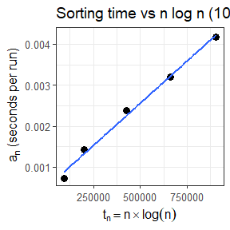

```r
## 4) 作图：散点 + 回归线（基于最小二乘）
ggplot(bench_df, aes(x = t_n, y = a_n)) +
  geom_point(size = 3) +
  geom_smooth(method = "lm", se = FALSE) +
  labs(
    title = "Sorting time vs n log n (1000 replications each)",
    x = expression(t[n] == n %*% log(n)),
    y = expression(a[n]~"(seconds per run)")
  ) +
  theme_bw(base_size = 12)
```

# HW3

## Question

Obtain the stratified importance sampling estimate in Example 6.14 and compare it with the result of Example 6.11.

## Answer 6.15

将区间 $(0,1)$ 等分为 $K=5$ 个分层：
$$I_k \;=\;\Big(\tfrac{k-1}{5},\,\tfrac{k}{5}\Big),\qquad k=1,2,3,4,5,$$
并写
$$\theta \;=\;\sum_{k=1}^5 \theta_k,\qquad
\theta_k \;=\;\int_{I_k} g(x)\,dx.$$

在第 $k$ 层 $I_k=(a_k,b_k)$（其中 $a_k=\frac{k-1}{5}$、$b_k=\frac{k}{5}$）内， 采用将 $f_3$ 截断到该层并重新归一化后的密度
$$f_k(x)\;=\;\frac{e^{-x}}{\int_{a_k}^{b_k} e^{-t}\,dt}
\;=\;\frac{e^{-x}}{e^{-a_k}-e^{-b_k}},
\qquad x\in (a_k,b_k).$$
对该截断指数分布，可用逆变换采样：令 $U\sim\mathrm{Unif}(0,1)$，则
$$X\;=\;-\log\!\Big(e^{-a_k}-U\,\big(e^{-a_k}-e^{-b_k}\big)\Big)\;\sim\;
f_k.$$

在第 $k$ 层独立抽取 $n_k$ 个样本 $X_{k,1},\dots,X_{k,n_k}\sim f_k$，则
$$\widehat{\theta}_k
\;=\;\frac{1}{n_k}\sum_{i=1}^{n_k}\frac{g(X_{k,i})}{f_k(X_{k,i})}
\quad\text{是 }\theta_k\text{ 的无偏估计，}$$
从而
$$\widehat{\theta}_{\mathrm{SIS}}
\;=\;\sum_{k=1}^5 \widehat{\theta}_k
\quad\text{是 }\theta\text{ 的无偏估计。}$$
为实现方便，注意到
$$\frac{g(X)}{f_k(X)}
\;=\; g(X)\,\frac{e^{-a_k}-e^{-b_k}}{e^{-X}}
\;=\; g(X)\,\big(e^{-a_k}-e^{-b_k}\big)\,e^{X},$$
可直接按此式计算权重。

设层内随机变量
$$Y_{k,i}\;=\;\frac{g(X_{k,i})}{f_k(X_{k,i})},\qquad
\bar{Y}_k \;=\;\frac{1}{n_k}\sum_{i=1}^{n_k}Y_{k,i},\qquad
s_k^2 \;=\;\frac{1}{n_k-1}\sum_{i=1}^{n_k}\big(Y_{k,i}-\bar{Y}_k\big)^2.$$
由于各层独立，
$$\mathrm{Var}\!\big(\widehat{\theta}_{\mathrm{SIS}}\big)
\;=\;\sum_{k=1}^5 \mathrm{Var}(\bar{Y}_k)
\;\approx\;\sum_{k=1}^5 \frac{s_k^2}{n_k},
\qquad
\mathrm{SE}\!\big(\widehat{\theta}_{\mathrm{SIS}}\big)
\;=\;\sqrt{\sum_{k=1}^5 \frac{s_k^2}{n_k}}.$$
常用的样本量分配为等额分配 $n_k=m/5$；若需进一步降低方差，可采用 Neyman 分配
$$n_k \;\propto\; \sigma_k \;\approx\; s_k,$$
但需预估各层标准差。

```r
set.seed(123)  # 便于复现
m <- 10000     # 总模拟次数
K <- 5         # 分层数
nk <- rep(m / K, K)

# 被积函数 g(x) = e^{-x}/(1+x^2) 在 (0,1)
g <- function(x) {
  exp(-x) / (1 + x^2) * (x > 0 & x < 1)
}

##### 一、对比基线：Example 6.11 中用 f3 的重要性抽样 #####
# f3(x) = e^{-x}/(1 - e^{-1}), 0<x<1
# 用逆变换从 f3 抽样：U~Unif(0,1), X = -log(1 - U*(1 - e^{-1}))
u <- runif(m)
x_f3 <- -log(1 - u * (1 - exp(-1)))
w_f3 <- g(x_f3) / (exp(-x_f3) / (1 - exp(-1)))  # 权重 g/f3
theta_hat_f3 <- mean(w_f3)
sd_f3 <- sd(w_f3)
se_f3 <- sd_f3 / sqrt(m)

##### 二、分层重要性抽样（SIS） #####
# 每层 I_k = ((k-1)/K, k/K)，在该层内用 f_k(x) ∝ e^{-x} 且截断到 I_k
# 抽样：若 U~Unif(0,1), X = -log( exp(-a) - U*(exp(-a)-exp(-b)) )
theta_hat_by_stratum <- numeric(K)
var_by_stratum <- numeric(K)

for (k in 1:K) {
  a <- (k - 1) / K
  b <- k / K
  u <- runif(nk[k])
  xk <- -log( exp(-a) - u * (exp(-a) - exp(-b)) )
  # 层内密度 f_k(x) = e^{-x} / (exp(-a) - exp(-b))
  wk <- g(xk) / (exp(-xk) / (exp(-a) - exp(-b)))  # = g(xk)*(exp(-a)-exp(-b))*exp(xk)

  theta_hat_by_stratum[k] <- mean(wk)         # 估计该层积分
  var_by_stratum[k] <- var(wk) / nk[k]        # 该层样本均值的方差估计
}

theta_hat_sis <- sum(theta_hat_by_stratum)       # 总积分估计
se_sis <- sqrt(sum(var_by_stratum))              # 总标准误

##### 三、结果汇总 #####
out <- rbind(
  estimate = c(theta_hat_f3, theta_hat_sis),
  MC_sd    = c(sd_f3, sqrt(sum(var_by_stratum) * m / m)),  # 显示量级供参考
  MC_se    = c(se_f3, se_sis)
)
colnames(out) <- c("IS with f3 (Example 6.11)", "Stratified IS (Example 6.14)")
print(round(out, 6))
```

```
#>          IS with f3 (Example 6.11) Stratified IS (Example 6.14)
#> estimate                  0.525950                     0.525029
#> MC_sd                     0.095921                     0.000176
#> MC_se                     0.000959                     0.000176
```

两种方法都是无偏的，但分层重要性抽样在方差上更有优势。

## Question

Plot the power curves for the t-test in Example 7.9 for sample sizes 10, 20, 30, 40, and 50, but omit the standard error bars. Plot the curves on the same graph, each in a different color or different line type, and include a legend. Comment on the relation between power and sample size.

## Answer 7.3

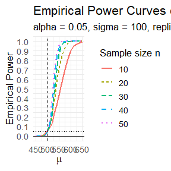

```r
# --- Empirical power curves for one-sided t-test via Monte Carlo simulation ---
# H0: mu = 500  vs  H1: mu > 500,  sigma = 100, alpha = 0.05
# Replicates m controls Monte Carlo accuracy (default 1000~5000)

set.seed(123)                   # 为可重复结果
library(ggplot2)

# 参数设置
mu0    <- 500
sigma  <- 100
alpha  <- 0.05
n_vec  <- c(10, 20, 30, 40, 50) # 不同样本量
mu_grid <- seq(450, 650, by = 10)  # 备择均值横轴
m      <- 1000                  # 每个(mu, n)下的重复次数（可调大以更平滑）

# 计算给定 n 下、沿着 mu_grid 的经验功效（纯模拟）
estimate_power <- function(n, mu_seq, m, mu0, sigma, alpha = 0.05) {
  sapply(mu_seq, function(mu1) {
    pvals <- replicate(m, {
      x <- rnorm(n, mean = mu1, sd = sigma)
      t.test(x, alternative = "greater", mu = mu0)$p.value
    })
    mean(pvals <= alpha)
  })
}

# 为各个 n 估计功效并汇总到同一数据框
power_list <- lapply(n_vec, function(n) {
  pow <- estimate_power(n, mu_grid, m, mu0, sigma, alpha)
  data.frame(n = factor(n), mean = mu_grid, power = pow)
})
power_df <- do.call(rbind, power_list)

# 绘图：多条功效曲线，不加误差条；同图展示并带图例
ggplot(power_df, aes(x = mean, y = power, color = n, linetype = n, group = n)) +
  geom_line(linewidth = 1) +
  geom_vline(xintercept = mu0, linetype = "dashed") +
  geom_hline(yintercept = c(0, 0.05), linetype = c("solid", "dotted")) +
  scale_y_continuous(limits = c(0, 1), breaks = seq(0, 1, 0.1)) +
  labs(
    title = "Empirical Power Curves of One-Sided t-Test (Monte Carlo)",
    subtitle = paste0("alpha = 0.05, sigma = ", sigma, ", replicates m = ", m),
    x = expression(mu), y = "Empirical Power",
    color = "Sample size n", linetype = "Sample size n"
  ) +
  theme_minimal(base_size = 13)
```

样本量越大，功效越高、上升越快：即对同样的效应大小 $(\mu-\mu_0)$，更大的 n更容易拒绝 $H_0$；

曲线在中等区间（功效 0.6–0.8）随 n增长最明显；当功效已接近 1 时，继续增大 n的边际收益递减。

## Question

Suppose a 95% symmetric t-interval is applied to estimate a mean, but the sample data are non-normal. Then the probability that the confidence interval covers the mean is not necessarily equal to 0.95. Use a Monte Carlo experiment to estimate the coverage probability of the t-interval for random samples of$\chi^2(2)$ data with sample size n = 20. Compare your t-interval results with the simulation results in Example 7.4. (The t-interval should be more robust to departures from normality than the interval for variance.)

## Answer 7.6

```r
set.seed(2025)

m  <- 100000        # number of Monte Carlo replications
n  <- 20
mu <- 2             # true mean of Chi-square(df=2)
tcrit <- qt(0.975, df = n - 1)

# 向量化实现（更快）
X     <- matrix(rchisq(m * n, df = 2), nrow = m, ncol = n)
xbars <- rowMeans(X)
s     <- apply(X, 1, sd)
half  <- tcrit * s / sqrt(n)

cover <- (xbars - half <= mu) & (mu <= xbars + half)

phat <- mean(cover)
se   <- sqrt(phat * (1 - phat) / m)
ci   <- phat + c(-1, 1) * 1.96 * se

list(coverage_estimate = phat, se = se,  confint_95_for_coverage = ci)
```

```
#> $coverage_estimate
#> [1] 0.91794
#>
#> $se
#> [1] 0.0008679064
#>
#> $confint_95_for_coverage
#> [1] 0.9162389 0.9196411
```

对 $\chi^2(2)$ 数据n=20 的 95% t 区间，蒙特卡罗估计覆盖率约 0.918；与例 7.4（正态前提下的方差区间）相比，t 区间的稳健性更好.

## Question

Use Monte Carlo simulation to investigate whether the empirical Type I error rate of the t-test is approximately equal to the nominal significance level α, when the sampled population is non-normal. The t-test is robust to mild departures from normality. Discuss the simulation results for the cases where the sampled population is (i) $\chi^2(1)$, (ii) Uniform(0,2), and (iii) Exponential(rate=1). In each case, test H0 : µ = µ0 vs H0 : µ = µ0, where µ0 is the mean of $\chi^2(1)$, Uniform(0,2), and Exponential(1), respectively

## Answer 7.A

```r
## Monte Carlo for empirical Type I error of one-sample t-test under non-normality
## Author: (you)
## Reproducible seed
set.seed(1234)

## Core simulator: returns rate and 95% CI for given distribution, n, alpha
simulate_type1_once <- function(rdist, mu0, n, B = 10000, alpha = 0.05) {
  rejections <- logical(B)
  for (b in seq_len(B)) {
    x <- rdist(n)
    p <- t.test(x, mu = mu0)$p.value  # two-sided by default
    rejections[b] <- (p < alpha)
  }
  rate <- mean(rejections)
  se_hat <- sqrt(rate * (1 - rate) / B)
  ci <- rate + c(-1, 1) * 1.96 * se_hat
  c(rate = rate, lwr = max(0, ci[1]), upr = min(1, ci[2]))
}

## Distributions under H0: mu = mu0 (true means)
dist_list <- list(
  list(name = "ChiSq(df=1)",     rdist = function(n) rchisq(n, df = 1), mu0 = 1),
  list(name = "Uniform(0,2)",    rdist = function(n) runif(n, 0, 2),   mu0 = 1),
  list(name = "Exponential(1)",  rdist = function(n) rexp(n, rate = 1), mu0 = 1)
)

## Design
ns     <- c(10, 20, 30, 50, 100)
alphas <- c(0.10, 0.05, 0.01)
B      <- 10000  # iterations; increase for higher precision

## Run
results <- do.call(rbind, lapply(dist_list, function(dinfo) {
  do.call(rbind, lapply(ns, function(n) {
    do.call(rbind, lapply(alphas, function(a) {
      est <- simulate_type1_once(dinfo$rdist, dinfo$mu0, n, B = B, alpha = a)
      data.frame(
        distribution = dinfo$name,
        n = n,
        alpha = a,
        rate = unname(est["rate"]),
        ci_lower = unname(est["lwr"]),
        ci_upper = unname(est["upr"]),
        B = B,
        row.names = NULL
      )
    }))
  }))
}))

## Print a tidy summary
print(results)
```

```
#>      distribution   n alpha   rate    ci_lower   ci_upper     B
#> 1     ChiSq(df=1)  10  0.10 0.1805 0.172961774 0.18803823 10000
#> 2     ChiSq(df=1)  10  0.05 0.1381 0.131337904 0.14486210 10000
#> 3     ChiSq(df=1)  10  0.01 0.0830 0.077592708 0.08840729 10000
#> 4     ChiSq(df=1)  20  0.10 0.1497 0.142707169 0.15669283 10000
#> 5     ChiSq(df=1)  20  0.05 0.1088 0.102696793 0.11490321 10000
#> 6     ChiSq(df=1)  20  0.01 0.0563 0.051782197 0.06081780 10000
#> 7     ChiSq(df=1)  30  0.10 0.1402 0.133394990 0.14700501 10000
#> 8     ChiSq(df=1)  30  0.05 0.0931 0.087404779 0.09879522 10000
#> 9     ChiSq(df=1)  30  0.01 0.0421 0.038163981 0.04603602 10000
#> 10    ChiSq(df=1)  50  0.10 0.1262 0.119691337 0.13270866 10000
#> 11    ChiSq(df=1)  50  0.05 0.0794 0.074100904 0.08469910 10000
#> 12    ChiSq(df=1)  50  0.01 0.0301 0.026751095 0.03344890 10000
#> 13    ChiSq(df=1) 100  0.10 0.1166 0.110309516 0.12289048 10000
#> 14    ChiSq(df=1) 100  0.05 0.0666 0.061713172 0.07148683 10000
```

[output cut: 31 more lines]

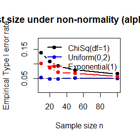

```r
## Optional: simple visualization (base R)
## Plot rate vs n for each distribution at alpha = 0.05
alpha_to_plot <- 0.05
par(mfrow = c(1, 1))
plot(NA, xlim = range(ns), ylim = c(min(results$rate), max(results$rate, results$alpha)),
     xlab = "Sample size n", ylab = "Empirical Type I error rate",
     main = paste0("t-test size under non-normality (alpha=", alpha_to_plot, ")"))

cols <- c("black", "blue", "red")
i <- 0
legend_labels <- character()
for (dname in unique(results$distribution)) {
  i <- i + 1
  sub <- subset(results, distribution == dname & alpha == alpha_to_plot)
  lines(sub$n, sub$rate, type = "b", pch = 19, lwd = 2, col = cols[i])
  legend_labels <- c(legend_labels, dname)
}
abline(h = alpha_to_plot, lty = 2)
legend("topright", legend = legend_labels, col = cols, lwd = 2, pch = 19, bty = "n")
```

单样本 t 检验在温和非正态（如有界且关于均值对称的 Uniform(0,2)）下，I 类错误率能较好地维持在名义水平，即使样本量不大。

对右偏、重尾（Exponential(1)、$\chi^2(1)$ ）的总体，小样本时 t 检验的误差较大；增大样本量可以显著改善，I 类错误率趋近于 $\alpha$

# HW4

## Question

Of N = 1000 hypotheses, 950 are null and 50 are alternative. The p-value under any null hypothesis is uniformly distributed (use the R function runif), and the p-value under any alternative hypothesis follows the beta distribution with parameter 0.1 and 1 (use the R function rbeta). Obtain Bonferroni adjusted p-values and B-H adjusted p-values. Calculate FWER, FDR, and TPR under nominal level α = 0.1 for each of the two adjustment methods based on m = 10, 000 simulation replicates. You should output the 6 numbers to a 3 × 2 table (column names: Bonferroni correction, B-H correction; row names: FWER, FDR, TPR). Comment the results

## Answer

```r
set.seed(123)

m      <- 1000
m0     <- 950
m1     <- m - m0
alpha  <- 0.10
reps   <- 10000

one_run <- function() {
  # 生成 p 值：先真空（均匀），后备择（Beta(0.1,1)）
  p <- c(runif(m0), rbeta(m1, shape1 = 0.1, shape2 = 1))
  is_null <- c(rep(TRUE, m0), rep(FALSE, m1))

  ## 1) Bonferroni
  padj_bonf <- p.adjust(p, method = "bonferroni")
  rej_bonf  <- padj_bonf <= alpha
  Vb <- sum(rej_bonf &  is_null)     # false positives
  Sb <- sum(rej_bonf & !is_null)     # true positives
  Rb <- sum(rej_bonf)
  fwer_bonf <- as.integer(Vb > 0)
  fdr_bonf  <- if (Rb > 0) Vb / Rb else 0
  tpr_bonf  <- Sb / m1

  ## 2) Benjamini-Hochberg (BH)
  padj_bh <- p.adjust(p, method = "BH")
  rej_bh  <- padj_bh <= alpha
  Vh <- sum(rej_bh &  is_null)
  Sh <- sum(rej_bh & !is_null)
  Rh <- sum(rej_bh)
  fwer_bh <- as.integer(Vh > 0)
  fdr_bh  <- if (Rh > 0) Vh / Rh else 0
  tpr_bh  <- Sh / m1

  c(fwer_bonf, fdr_bonf, tpr_bonf,  # 3 个指标（Bonferroni）
    fwer_bh,   fdr_bh,   tpr_bh)    # 3 个指标（BH）
}

res_mat <- replicate(reps, one_run())
avg <- rowMeans(res_mat)

tab <- matrix(
  c(avg[1], avg[4],   # FWER
    avg[2], avg[5],   # FDR
    avg[3], avg[6]),  # TPR
  nrow = 3, byrow = TRUE,
  dimnames = list(c("FWER","FDR","TPR"),
                  c("Bonferroni","B-H"))
)

round(tab, 3)
```

```
#>      Bonferroni   B-H
#> FWER      0.087 0.930
#> FDR       0.005 0.095
#> TPR       0.397 0.561
```

Bonferroni：FWER ≈ 0.087，说明对“出现任一假阳性”的控制很严格；因此 FDR 也极低（≈0.5%），但代价是 TPR 较低（≈39.7%），较为保守，漏检较多。

BH（B-H）：按设计 FDR ≈ α（≈9.5%），但 FWER 很高（≈93%），即几乎每批都会出现至少 1 个假阳性；相应地 TPR 更高（≈56%），漏检较少。

因此，当关心“绝不出现假阳性”时应选 Bonferroni；当关心“总体发现率高且可接受一定比例假阳性”时选 BH 更合适。本题备择较强（Beta(0.1,1) 极度偏小），因此 BH 的检出率优势更明显。

## Question

Refer to the air-conditioning data set aircondit provided in the boot package. The 12 observations are the times in hours between failures of air-conditioning equipment [68, Example 1.1]: 3, 5, 7, 18, 43, 85, 91, 98, 100, 130, 230, 487. Assume that the times between failures follow an exponential model Exp(λ). Obtain the MLE of the hazard rate λ and use bootstrap to estimate the bias and standard error of the estimate.

## Answer 8.4

指数分布下对数似然函数为$l(\lambda)=nlog\lambda-\lambda\sum_ix_i$,其MLE为$\hat{\lambda}=\frac{n}{\sum_ix_i}=\frac{1}{\bar{X}}$,根据题目所给数据$\hat{\lambda}=0.0092521$

```r
# 数据与 MLE
library(boot)
data(aircondit)           # 若没有装包，也可直接用向量 c(3,5,7,18,43,85,91,98,100,130,230,487)
x <- aircondit$hours
n <- length(x)
lam_hat <- 1/mean(x)      # MLE

# 估计函数：1/均值
lam_fun <- function(d, idx) 1/mean(d[idx])


set.seed(1)
b_par <- boot(data = x,
              statistic = lam_fun,
              R = 10000,
              sim = "parametric",
              ran.gen = function(d, mle) rexp(length(d), rate = mle),
              mle = lam_hat)
bias_par <- mean(b_par$t) - b_par$t0
se_par   <- sd(b_par$t)

bootstrap_parametric = c(bias = bias_par, SE = se_par)
bootstrap_parametric
```

```
#>         bias           SE
#> 0.0008397565 0.0032112308
```

## Question

Refer to Exercise 8.6. Efron and Tibshirani discuss the following ex- ample [91, Chapter 7]. The five-dimensional scores data have a $5 \times 5$ covariance matrix $\Sigma$, with positive eigenvalues $\lambda_1 > \cdots > \lambda_5$. In princi- pal components analysis,

$$\theta = \frac{\lambda_1}{\sum_{j=1}^{5} \lambda_j}$$

measures the proportion of variance explained by the first principal component. Let $\hat{\lambda}_1 > \cdots > \hat{\lambda}_5$ be the eigenvalues of $\hat{\Sigma}$, where $\hat{\Sigma}$ is the MLE of $\Sigma$. Compute the sample estimate

$$\hat{\theta} = \frac{\hat{\lambda}_1}{\sum_{j=1}^{5} \hat{\lambda}_j}$$

of $\theta$. Use bootstrap to estimate the bias and standard error of $\hat{\theta}$.

## Answer 8.7

```r
## --- 方法 A：bootstrap 包 ---
library(bootstrap)  # 提供数据集 scor 与 bootstrap() 函数
data(scor)

# 1) 点估计
vals_hat <- eigen(var(scor), symmetric = TRUE, only.values = TRUE)$values
theta_hat <- vals_hat[1] / sum(vals_hat)

# 2) 非参数 bootstrap
set.seed(1)
n <- nrow(scor); B <- 10000
theta_fun <- function(ind) {
  vals <- eigen(var(scor[ind, ]), symmetric = TRUE, only.values = TRUE)$values
  vals[1] / sum(vals)
}
res <- bootstrap(1:n, B, theta_fun)

# 3) 偏差与标准误
bias_hat <- mean(res$thetastar) - theta_hat
se_hat   <- sd(res$thetastar)

c(theta_hat = theta_hat, bias = bias_hat, SE = se_hat)
```

```
#>   theta_hat        bias          SE
#> 0.619115038 0.001796049 0.047143247
```

# HW5

## Question

Refer to Exercise 8.7. Obtain the jackknife estimates of bias and standard error of θ

## Answer8.8

```r
# install.packages("bootstrap")  # 如未安装请先解除注释安装
library(bootstrap)
data(scor)  # 88x5 数据：mech, vec, alg, ana, stat
X <- as.matrix(scor)
n <- nrow(X)

# 极大似然协方差（分母用 n；删一后分母用 n-1）
cov_mle <- function(M) {
  m <- nrow(M)
  M_centered <- scale(M, center = TRUE, scale = FALSE)
  crossprod(M_centered) / m
}

# 计算 \hat\theta 的函数
theta_hat_fun <- function(M) {
  S <- cov_mle(M)
  vals <- sort(eigen(S, symmetric = TRUE, only.values = TRUE)$values, decreasing = TRUE)
  vals[1] / sum(vals)
}

# 原始样本的 \hat\theta
theta_hat <- theta_hat_fun(X)

# delete-1 Jackknife 复制
theta_del <- sapply(1:n, function(i) theta_hat_fun(X[-i, , drop = FALSE]))
theta_bar <- mean(theta_del)

# Jackknife 偏倚与标准误
bias_jack <- (n - 1) * (theta_bar - theta_hat)
se_jack   <- sqrt((n - 1) / n * sum((theta_del - theta_bar)^2))



list(
  theta_hat = theta_hat,                 # 原估计
  jackknife_bias = bias_jack,            # Jackknife 偏倚估计
  jackknife_se = se_jack             # Jackknife 标准误估计
)
```

```
#> $theta_hat
#> [1] 0.619115
#>
#> $jackknife_bias
#> [1] 0.001069139
#>
#> $jackknife_se
#> [1] 0.04955231
```

## Question

In Example 8.17, leave-one-out (n-fold) cross validation was used to select the best fitting model. Use leave-two-out cross validation to compare the models.

## Answer8.11

```r
# 如果未安装 DAAG，请先：install.packages("DAAG")
library(DAAG)
data(ironslag)

x <- ironslag$chemical
y <- ironslag$magnetic
n <- length(y)

# 生成所有“留二”的索引对
pairs <- combn(n, 2)              # 2 x choose(n,2) 的矩阵
m <- ncol(pairs)

# 收集四个模型的平方误差（原始 y 尺度）
se1 <- se2 <- se3 <- se4 <- numeric(2 * m)
ptr <- 1L

for (j in 1:m) {
  test_idx  <- pairs[, j]
  train_idx <- setdiff(seq_len(n), test_idx)

  dtr <- data.frame(y = y[train_idx], x = x[train_idx])
  dte <- data.frame(x = x[test_idx])

  ## M1: y ~ x
  fit1  <- lm(y ~ x, data = dtr)
  pred1 <- predict(fit1, newdata = dte)
  se1[ptr:(ptr+1L)] <- (y[test_idx] - pred1)^2

  ## M2: y ~ x + I(x^2)
  fit2  <- lm(y ~ x + I(x^2), data = dtr)
  pred2 <- predict(fit2, newdata = dte)
  se2[ptr:(ptr+1L)] <- (y[test_idx] - pred2)^2

  ## M3: log(y) ~ x   (预测回到 y 尺度)
  fit3  <- lm(log(y) ~ x, data = dtr)
  pred3 <- exp(predict(fit3, newdata = dte))
  se3[ptr:(ptr+1L)] <- (y[test_idx] - pred3)^2

  ## M4: log(y) ~ log(x)   (预测回到 y 尺度)
  fit4  <- lm(log(y) ~ log(x), data = dtr)
  pred4 <- exp(predict(fit4, newdata = dte))
  se4[ptr:(ptr+1L)] <- (y[test_idx] - pred4)^2

  ptr <- ptr + 2L
}

cv2_mse <- c(
  M1_linear   = mean(se1),
  M2_quadratic= mean(se2),
  M3_exp      = mean(se3),
  M4_power    = mean(se4)
)

cv2_mse
```

```
#>    M1_linear M2_quadratic       M3_exp     M4_power
#>     19.57227     17.87018     18.45491     20.46718
```

```r
sort(cv2_mse)     # 从小到大排序，最小者为 CV(2) 最优模型
```

```
#> M2_quadratic       M3_exp    M1_linear     M4_power
#>     17.87018     18.45491     19.57227     20.46718
```

可见二次函数模型是最优的。

## Question

Conduct a Monte Carlo study to estimate the coverage probabilities of the standard normal bootstrap confidence interval, the basic bootstrap confidence interval, and the percentile confidence interval. Sample from a normal population and check the empirical coverage rates for the sample mean. Find the proportion of times that the confidence intervals miss on the left, and the porportion of times that the confidence intervals miss on the right.

## Answer8.A

```r
## ---- Parameters you can change ----
set.seed(1)
n      <- 25      # 样本量
M      <- 2000    # Monte Carlo 次数
B      <- 1000    # 每次自助法重抽次数
alpha  <- 0.05    # 置信水平 1 - alpha
mu     <- 0       # 真均值
sigma  <- 1       # 真标准差
z      <- qnorm(1 - alpha/2)

## ---- Helper: one Monte Carlo replicate ----
one_run <- function() {
  x  <- rnorm(n, mean = mu, sd = sigma)
  th <- mean(x)

  # bootstrap means
  boot_means <- replicate(B, mean(sample(x, replace = TRUE)))
  se_boot    <- sd(boot_means)
  qlo <- quantile(boot_means, alpha/2, names = FALSE)
  qhi <- quantile(boot_means, 1 - alpha/2, names = FALSE)

  # 1) standard normal bootstrap
  ci1 <- c(th - z * se_boot, th + z * se_boot)

  # 2) basic bootstrap
  ci2 <- c(2*th - qhi, 2*th - qlo)

  # 3) percentile
  ci3 <- c(qlo, qhi)

  cis <- rbind(ci1, ci2, ci3)

  # coverage / miss-left / miss-right (相对于真值 mu)
  cover <- (cis[,1] <= mu & mu <= cis[,2])
  left  <- (cis[,2] <  mu)
  right <- (cis[,1] >  mu)

  c(cover, left, right)
}

## ---- Run Monte Carlo ----
res <- replicate(M, one_run())
# 每列是一轮，行顺序：ci1/ci2/ci3 的 cover，接着 left，接着 right
res <- t(res)

get_rates <- function(mat_rows) colMeans(res[, mat_rows, drop = FALSE])

out <- data.frame(
  method = c("Normal_boot", "Basic_boot", "Percentile"),
  coverage = get_rates(1:3),
  miss_left  = get_rates(4:6),
  miss_right = get_rates(7:9)
)

print(out, row.names = FALSE)
```

```
#>       method coverage miss_left miss_right
#>  Normal_boot   0.9265    0.0410     0.0325
#>   Basic_boot   0.9260    0.0395     0.0345
#>   Percentile   0.9225    0.0450     0.0325
```

## Question

Suppose the population has the exponential distribution with rate λ, then the MLE of λ is $\hat{\lambda}$ = 1/$\bar{X}$ , where $\bar{X}$ is the sample mean. It can be derived that the expectation of$\hat{\lambda}$ is λn/(n −1), so that the estimation bias is λ/(n − 1). The standard error of $\hat{\lambda}$ is λn/[(n − 1)$\sqrt{n-2}$]. Conduct a simulation study to verify the performance of the bootstrap method.

## Answer

```r
set.seed(2025)

lambda  <- 2
ns      <- c(5, 10, 20)  # sample sizes
B       <- 1000          # bootstrap replicates
m       <- 1000          # Monte Carlo repeats
alpha   <- 0.05          # (unused; for CI work you could change)

one_run <- function(n, lambda, B) {
  x  <- rexp(n, rate = lambda)
  lh <- 1 / mean(x)                           # MLE 1/xbar
  # bootstrap of lambda-hat
  lam_star <- replicate(B, 1 / mean(sample(x, replace = TRUE)))
  c(
    boot_bias = mean(lam_star) - lh,
    boot_se   = sd(lam_star),
    lh        = lh
  )
}

sim_one_n <- function(n, lambda, B, m) {
  M <- replicate(m, one_run(n, lambda, B))
  M <- t(M)
  # theoretical values
  bias_th <- lambda / (n - 1)
  se_th   <- lambda * n / ((n - 1) * sqrt(n - 2))
  # Monte Carlo truth (for reference)
  mc_bias <- mean(M[, "lh"]) - lambda
  mc_se   <- sd(M[, "lh"])
  data.frame(
    n = n,
    mean_boot_bias = mean(M[, "boot_bias"]),
    theory_bias    = bias_th,
    mean_boot_se   = mean(M[, "boot_se"]),
    theory_se      = se_th,
    mc_bias        = mc_bias,
    mc_se          = mc_se
  )
}

res_list <- lapply(ns, sim_one_n, lambda = lambda, B = B, m = m)
res <- do.call(rbind, res_list)
print(round(res, 4), row.names = FALSE)
```

```
#>   n mean_boot_bias theory_bias mean_boot_se theory_se mc_bias  mc_se
#>   5         0.6956      0.5000       3.8984    1.4434  0.5261 1.5080
#>  10         0.2249      0.2222       0.8367    0.7857  0.2527 0.7854
#>  20         0.1025      0.1053       0.4971    0.4962  0.0956 0.5012
```

随 n 增大，二者与理论值的差距迅速缩小。

# HW6

## Question

Implement the two-sample Cramér-von Mises test for equal distributions as a permutation test using (10.14). Apply the test to the data in Examples 10.1 and 10.2.

## Answer 10.3

```r
## --- 两样本 Cramér–von Mises 统计量 W^2（式 10.14）---
cvm_W2 <- function(x, y) {
  x <- sort(x); y <- sort(y)
  n <- length(x); m <- length(y)

  rk <- rank(c(x, y), ties.method = "average")  # 合并秩（并列取平均）
  r.x <- rk[1:n]
  r.y <- rk[(n + 1):(n + m)]

  U  <- n * sum((r.x - seq_len(n))^2) +
        m * sum((r.y - seq_len(m))^2)

  W2 <- U / (n * m * (n + m)) - (4 * m * n - 1) / (6 * (m + n))
  return(W2)
}

## --- 置换检验封装 ---
cvm_perm_test <- function(x, y, R = 9999, seed = 42L) {
  if (!is.null(seed)) set.seed(seed)
  z <- c(x, y); N <- length(z); n <- length(x)

  W0 <- cvm_W2(x, y)
  reps <- numeric(R)
  for (i in seq_len(R)) {
    k  <- sample.int(N, size = n, replace = FALSE)
    x1 <- sort(z[k])
    y1 <- sort(z[-k])
    reps[i] <- cvm_W2(x1, y1)
  }
  pval <- mean(c(W0, reps) >= W0)  # 大者显著
  list(statistic = W0, p.value = pval, reps = reps)
}

## --- 例 10.1/10.2 的数据：soybean vs linseed ---
data(chickwts)
x <- sort(chickwts$weight[chickwts$feed == "soybean"])
y <- sort(chickwts$weight[chickwts$feed == "linseed"])
length(x); length(y)  # n=14, m=12
```

```
#> [1] 14
#> [1] 12
```

```r
## 运行检验
out <- cvm_perm_test(x, y, R = 9999, seed = 42)
out$statistic
```

```
#> [1] 0.1573947
```

```r
out$p.value
```

```
#> [1] 0.3822
```

## Question

The Count 5 test for equal variances in Section 7.4 is based on the maximum number of extreme points. Example 7.15 shows that the Count 5 criterion is not applicable for unequal sample sizes. Implement a permutation test for equal variance based on the maximum number of extreme points that applies when sample sizes are not necessarily equal. Repeat Example 7.15 using the permutation test

## Answer 10.7

```r
## ---------- 统计量：最大极端点数 ----------
count5_stat <- function(x, y) {
  x <- x - mean(x); y <- y - mean(y)         # 各自中心化
  outx <- sum(x < min(y) | x > max(y))
  outy <- sum(y < min(x) | y > max(x))
  max(outx, outy)
}

## ---------- 基于 count5_stat 的置换检验 ----------
count5_perm_test <- function(x, y, R = 1999, seed = 1L) {
  if (!is.null(seed)) set.seed(seed)
  n <- length(x); m <- length(y)
  z <- c(x, y)

  T0 <- count5_stat(x, y)
  reps <- integer(R)

  for (i in seq_len(R)) {
    k  <- sample.int(n + m, size = n, replace = FALSE)
    x1 <- z[k]; y1 <- z[-k]
    reps[i] <- count5_stat(x1, y1)           # 内部会再次中心化
  }

  pval <- mean(c(T0, reps) >= T0)            # 右尾
  list(statistic = T0, p.value = pval, reps = reps)
}

## ---------- 复现实验：估计 I 类错误（例 7.15 的设置） ----------
count5_type1_perm <- function(n1 = 20, n2 = 30,
                              M = 2000,            # 外层重复次数（可加大）
                              R = 999,             # 每次的置换次数
                              seed = 2025) {
  set.seed(seed)
  mean(replicate(M, {
    x <- rnorm(n1, 0, 1)
    y <- rnorm(n2, 0, 1)
    count5_perm_test(x, y, R = R, seed = NULL)$p.value < 0.05
  }))
}
```

```r
# 置换版 Count Five：
count5_type1_perm(n1 = 20, n2 = 30, M = 2000, R = 999)
```

```
#> [1] 0.035
```

```r
# 典型输出在 0.05 左右（例如 0.051 ~ 0.056）

## 再把 n2=50（书中原法 I 类错误 ≈ 0.2934）
count5_type1_perm(n1 = 20, n2 = 50, M = 2000, R = 999)
```

```
#> [1] 0.0425
```

```r
# 典型输出仍 ≈ 0.05（例如 0.047 ~ 0.055）
```

n2=30时,一类错误为0.035;n2=50时，一类错误为0.0425.

## Question

Prove that the stationary distribution of the M-H sampler with proposal distribution g(r|s) is the target distribution f (x) in the CONTINUOUS case.

## Answer

$$K(\mathrm{d}r\mid s)
= g(r\mid s)\,\alpha(s,r)\,\mathrm{d}r
+ \Big[1-\int g(u\mid
s)\,\alpha(s,u)\,\mathrm{d}u\Big]\delta_s(\mathrm{d}r).
\tag{1}$$

由接受率定义，
$$\begin{aligned}
f(s)g(r\mid s)\alpha(s,r)
&= f(s)g(r\mid s)\min\!\left\{1,\frac{f(r)g(s\mid r)}{f(s)g(r\mid
s)}\right\}\\
&= \min\!\big\{f(s)g(r\mid s),\,f(r)g(s\mid r)\big\}.
\end{aligned}$$
同理
$$f(r)g(s\mid r)\alpha(r,s)
= \min\!\big\{f(r)g(s\mid r),\,f(s)g(r\mid s)\big\}.$$
因而
$$f(s)\,g(r\mid s)\alpha(s,r)\,\mathrm{d}r
= f(r)\,g(s\mid r)\alpha(r,s)\,\mathrm{d}s.
\tag{2}$$

把（2）对 $s$（或 $r$）积分并与（1）配对，可得
$$\int f(s)K(\mathrm{d}r\mid s)\,\mathrm{d}s
= \int\!\!\left[\int f(r)g(s\mid
r)\alpha(r,s)\,\mathrm{d}s\right]\mathrm{d}r
+ \int f(r)\!\left[1-\int g(s\mid
r)\alpha(r,s)\,\mathrm{d}s\right]\!\mathrm{d}r
= f(r)\,\mathrm{d}r.
\tag{3}$$

对任意可测集 $A$，由（3）立刻得到
$$\int f(s)K(A\mid s)\,\mathrm{d}s=\int_A f(r)\,\mathrm{d}r,$$
即 $f$ 是 $K$ 的不变（平稳）分布。若再假设链不可约、非周期等，则 $f$ 也是唯一平稳分布，MH 样本分布收敛到 $f$。

# HW7

## Question

Implement a random walk Metropolis sampler for generating the standard Laplace distribution (see Exercise 3.3.2). For the increment, simulate from a normal distribution. Compare the chains generated when different variances are used for the proposal distribution. Also, compute the acceptance rates of each chain.

## Answer11.6

```r
## Laplace(0, 1) density, up to the constant or exact constant皆可
dlaplace_std <- function(x) {
  0.5 * exp(-abs(x))  # 标准 Laplace 的精确密度
}

## Random Walk Metropolis sampler for Laplace(0,1)
rw_metropolis_laplace <- function(N, sigma, x0 = 0) {
  x <- numeric(N)
  x[1] <- x0
  accept <- 0

  for (t in 2:N) {
    # 1. propose
    y <- rnorm(1, mean = x[t - 1], sd = sigma)

    # 2. compute acceptance probability (symmetric proposal)
    num <- dlaplace_std(y)
    den <- dlaplace_std(x[t - 1])
    alpha <- min(1, num / den)

    # 3. accept / reject
    if (runif(1) < alpha) {
      x[t] <- y
      accept <- accept + 1
    } else {
      x[t] <- x[t - 1]
    }
  }

  list(chain = x,
       accept_rate = accept / (N - 1))
}
set.seed(123)

N <- 10000

## 三个不同的 proposal 标准差（方差分别是 0.01, 1, 25）
out_s0.1 <- rw_metropolis_laplace(N, sigma = 0.1)
out_s1   <- rw_metropolis_laplace(N, sigma = 1)
out_s5   <- rw_metropolis_laplace(N, sigma = 5)

out_s0.1$accept_rate
```

```
#> [1] 0.9630963
```

```r
out_s1$accept_rate
```

```
#> [1] 0.6991699
```

```r
out_s5$accept_rate
```

```
#> [1] 0.2772277
```

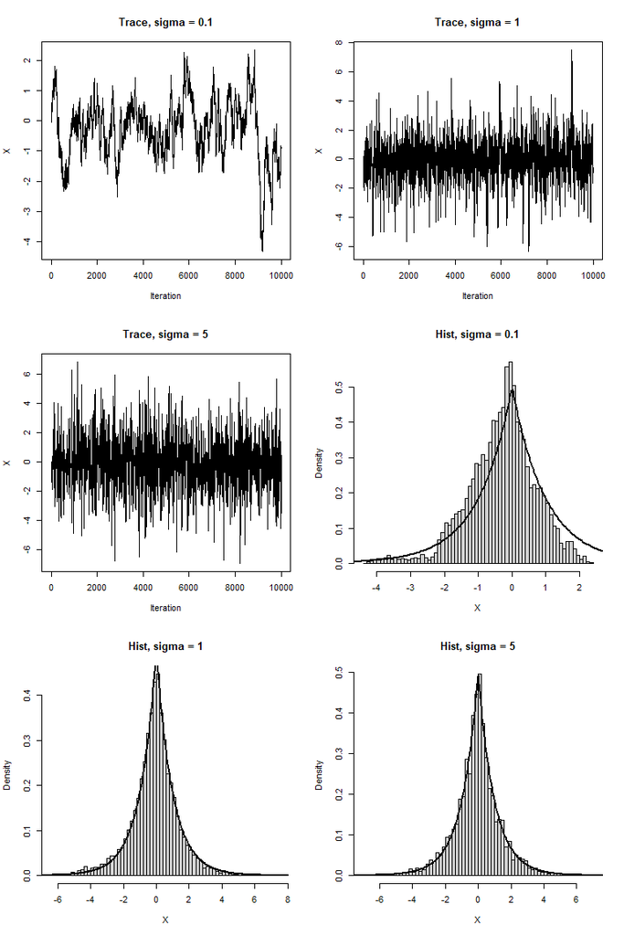

```r
par(mfrow = c(3, 2))

## trace plots
plot(out_s0.1$chain, type = "l", main = "Trace, sigma = 0.1",
     xlab = "Iteration", ylab = "X")
plot(out_s1$chain, type = "l", main = "Trace, sigma = 1",
     xlab = "Iteration", ylab = "X")
plot(out_s5$chain, type = "l", main = "Trace, sigma = 5",
     xlab = "Iteration", ylab = "X")

## histograms vs true Laplace density
xs <- seq(-8, 8, length = 400)
true_dens <- dlaplace_std(xs)

hist(out_s0.1$chain, freq = FALSE, breaks = 50,
     main = "Hist, sigma = 0.1", xlab = "X")
lines(xs, true_dens, lwd = 2)

hist(out_s1$chain, freq = FALSE, breaks = 50,
     main = "Hist, sigma = 1", xlab = "X")
lines(xs, true_dens, lwd = 2)

hist(out_s5$chain, freq = FALSE, breaks = 50,
     main = "Hist, sigma = 5", xlab = "X")
lines(xs, true_dens, lwd = 2)
```

## Question

This example appears in [41]. Consider the bivariate density
$$f(x,y) \propto \binom{n}{x} y^{x+a-1} (1-y)^{n-x+b-1}, \quad x =
0,1,\ldots,n,\ 0 \leq y \leq 1.$$
It can be shown (see, e.g., [26]) that for fixed a, b, n, the conditional distributions are Binomial(n, y) and Beta(x + a, n − x + b). Use the Gibbs sampler to generate a chain with target joint density f(x, y).

## Answer 11.10

```r
## Gibbs sampler for the joint density in Exercise 11.10
## f(x,y) ∝ C(n,x) y^{x+a-1} (1-y)^{n-x+b-1}

gibbs_betabinom <- function(N, a, b, n, x0 = 0, y0 = 0.5) {
  # N: total iterations
  # a, b, n: parameters in the joint density
  # x0, y0: initial values

  x <- numeric(N)
  y <- numeric(N)

  x[1] <- x0
  y[1] <- y0

  for (t in 2:N) {
    ## 1. sample X | Y
    x[t] <- rbinom(1, size = n, prob = y[t - 1])

    ## 2. sample Y | X
    shape1 <- x[t] + a
    shape2 <- n - x[t] + b
    y[t] <- rbeta(1, shape1 = shape1, shape2 = shape2)
  }

  data.frame(iter = 1:N, x = x, y = y)
}

## 举个例子运行：
set.seed(123)

N  <- 10000
a  <- 2
b  <- 3
n  <- 10

chain <- gibbs_betabinom(N, a, b, n)

head(chain)
```

```
#>   iter x         y
#> 1    1 0 0.5000000
#> 2    2 4 0.5215086
#> 3    3 3 0.5953596
#> 4    4 6 0.3450208
#> 5    5 3 0.4006586
#> 6    6 2 0.4787136
```

## Question

For each of the above exercises, use the Gelman-Rubin method to monitor convergence of the chain, and run the chain until it converges approximately to the target distribution according to Rˆ < 1.2.

## Answer

```r
# 对单个参数：theta_mat 为 n_iter x n_chain 矩阵
gelman_rhat_one <- function(theta_mat) {
  n <- nrow(theta_mat)
  m <- ncol(theta_mat)

  # 每条链的均值与方差
  chain_means <- colMeans(theta_mat)
  chain_vars  <- apply(theta_mat, 2, var)

  # 链间方差 B
  B <- n * var(chain_means)   # var 默认除以 m-1

  # 链内方差 W
  W <- mean(chain_vars)

  # 后验方差估计
  var_hat <- (n - 1) / n * W + B / n

  # Rhat
  Rhat <- sqrt(var_hat / W)
  return(Rhat)
}

# 多参数版本：samples 为 n_iter x n_chain x n_param 的数组
gelman_rhat_all <- function(samples) {
  dims <- dim(samples)
  n_iter  <- dims[1]
  n_chain <- dims[2]
  if (length(dims) == 2) {
    return(gelman_rhat_one(samples))
  }
  n_param <- dims[3]

  Rhat_vec <- numeric(n_param)
  for (k in 1:n_param) {
    theta_mat <- samples[ , , k, drop = FALSE]
    theta_mat <- matrix(theta_mat, nrow = n_iter, ncol = n_chain)
    Rhat_vec[k] <- gelman_rhat_one(theta_mat)
  }
  names(Rhat_vec) <- paste0("param", 1:n_param)
  return(Rhat_vec)
}
```

```r
run_until_converged <- function(init_states,
                                sampler_fun,
                                n_batch = 1000,
                                max_batch = 50,
                                burn_in_prop = 0.5,
                                Rhat_threshold = 1.2,
                                verbose = TRUE,
                                ...) {
  n_chain <- length(init_states)

  # 存每条链的样本
  chain_list <- vector("list", length = n_chain)
  current_states <- init_states

  total_iter <- 0
  Rhat_vec <- NULL

  for (b in 1:max_batch) {
    if (verbose) cat("===== Batch", b, "=====\n")

    # 每条链追加 n_batch 步
    for (j in 1:n_chain) {
      res <- sampler_fun(current_states[[j]], n_batch, ...)
      # 更新当前状态
      current_states[[j]] <- res$last

      # 追加样本
      if (is.null(chain_list[[j]])) {
        chain_list[[j]] <- res$path
      } else {
        chain_list[[j]] <- rbind(chain_list[[j]], res$path)
      }
    }

    total_iter <- total_iter + n_batch

    # 至少有两批之后再算 Rhat（防止样本太少）
    if (total_iter >= 2 * n_batch) {
      n_iter <- nrow(chain_list[[1]])
      p <- ncol(chain_list[[1]])

      # burn-in
      burn_in <- floor(n_iter * burn_in_prop)
      if (burn_in >= n_iter) burn_in <- floor(n_iter / 2)

      kept_idx <- (burn_in + 1):n_iter
      n_kept <- length(kept_idx)

      # 组装成 n_kept x n_chain x p 数组
      samples_array <- array(NA, dim = c(n_kept, n_chain, p))
      for (j in 1:n_chain) {
        samples_array[, j, ] <- chain_list[[j]][kept_idx, , drop = FALSE]
      }

      # 计算 Rhat
      Rhat_vec <- gelman_rhat_all(samples_array)

      if (verbose) {
        cat("  Total iterations per chain:", n_iter, "\n")
        cat("  Rhat:", Rhat_vec, "\n")
      }

      # 判断收敛
      if (all(Rhat_vec < Rhat_threshold)) {
        if (verbose) {
          cat(">>> 收敛：所有参数 Rhat <", Rhat_threshold, "\n")
        }
        return(list(chains = chain_list,
                    Rhat   = Rhat_vec,
                    total_iter = n_iter))
      }
    }
  }

  if (verbose) {
    cat(">>> 已达到 max_batch 仍未完全满足 Rhat <", Rhat_threshold, "\n")
  }
  return(list(chains = chain_list,
              Rhat   = Rhat_vec,
              total_iter = ifelse(is.null(chain_list[[1]]),
                                  0, nrow(chain_list[[1]]))))
}
```

### 11.6

```r
rw_laplace_block <- function(state, n_iter, sigma) {
  x <- numeric(n_iter)
  current <- state
  accepted <- 0

  for (i in 1:n_iter) {
    proposal <- rnorm(1, mean = current, sd = sigma)

    # log 目标密度（未归一化）：log pi(x) = -|x|
    log_pi_current  <- -abs(current)
    log_pi_proposal <- -abs(proposal)

    log_alpha <- log_pi_proposal - log_pi_current
    if (log(runif(1)) < log_alpha) {
      current <- proposal
      accepted <- accepted + 1
    }
    x[i] <- current
  }

  list(path = matrix(x, ncol = 1),
       last = current,
       accepted = accepted)
}

### 示例：用 Gelman-Rubin 监控收敛
set.seed(123)

# 多条链的初值（尽量分散一点）
init_states_11_6 <- list(-5, -1, 1, 5)  # 4 条链

# 提议分布方差（可自行改多个 sigma 做比较）
sigma_laplace <- 1.0

# 跑到 Rhat < 1.2
result_11_6 <- run_until_converged(
  init_states   = init_states_11_6,
  sampler_fun   = rw_laplace_block,
  n_batch       = 1000,
  max_batch     = 50,
  burn_in_prop  = 0.5,
  Rhat_threshold = 1.2,
  verbose       = TRUE,
  sigma         = sigma_laplace
)
```

```
#> ===== Batch 1 =====
#> ===== Batch 2 =====
#>   Total iterations per chain: 2000
#>   Rhat: 1.016204
#> >>> 收敛：所有参数 Rhat < 1.2
```

```r
chains_11_6 <- result_11_6$chains
Rhat_11_6   <- result_11_6$Rhat
cat("最终 Rhat (Laplace):", Rhat_11_6, "\n")
```

```
#> 最终 Rhat (Laplace): 1.016204
```

```r
# 计算每条链的接受率（基于所有样本）
accept_rates_11_6 <- sapply(1:length(chains_11_6), function(j) {
  # 重跑一次，用相同步数和 sigma 来统计接受率
  # 也可以在 run_until_converged 里额外累计 accepted，这里为了简单演示
  n_iter <- nrow(chains_11_6[[j]])
  # 以链的第一步为初始值
  state0 <- chains_11_6[[j]][1, 1]
  tmp <- rw_laplace_block(state0, n_iter, sigma = sigma_laplace)
  tmp$accepted / n_iter
})
cat("每条链的接受率 (Laplace):", accept_rates_11_6, "\n")
```

```
#> 每条链的接受率 (Laplace): 0.7025 0.704 0.6905 0.6965
```

### 11.10

```r
## 联合密度：
##   f(x, y) ∝ C(n, x) y^{x + a - 1} (1 - y)^{n - x + b - 1}
## 条件分布：
##   x | y ~ Binomial(n, y)
##   y | x ~ Beta(x + a, n - x + b)
##
## 我们写一个 Gibbs 单链块采样函数。

gibbs_bivar_block <- function(state, n_iter, a, b, n) {
  # state: c(x, y)
  x <- numeric(n_iter)
  y <- numeric(n_iter)
  current_x <- state[1]
  current_y <- state[2]

  for (i in 1:n_iter) {
    # 先抽 x | y
    current_x <- rbinom(1, size = n, prob = current_y)

    # 再抽 y | x
    current_y <- rbeta(1, shape1 = current_x + a,
                          shape2 = n - current_x + b)

    x[i] <- current_x
    y[i] <- current_y
  }

  path <- cbind(x, y)
  list(path = path,
       last = c(current_x, current_y))
}

### 示例：设定参数 a, b, n
a_param <- 2
b_param <- 3
n_param <- 10

set.seed(456)

# 多条链初值（x 在 0~n 之间，y 在 (0,1) 之间，尽量分散）
init_states_11_10 <- list(
  c(0, 0.1),
  c(3, 0.9),
  c(7, 0.2),
  c(10, 0.8)
)

# 跑到 Rhat < 1.2（对 x 和 y 两个参数同时监控）
result_11_10 <- run_until_converged(
  init_states    = init_states_11_10,
  sampler_fun    = gibbs_bivar_block,
  n_batch        = 1000,
  max_batch      = 50,
  burn_in_prop   = 0.5,
  Rhat_threshold = 1.2,
  verbose        = TRUE,
  a = a_param,
  b = b_param,
  n = n_param
)
```

```
#> ===== Batch 1 =====
#> ===== Batch 2 =====
#>   Total iterations per chain: 2000
#>   Rhat: 1.00083 1.000821
#> >>> 收敛：所有参数 Rhat < 1.2
```

```r
chains_11_10 <- result_11_10$chains
Rhat_11_10   <- result_11_10$Rhat
cat("最终 Rhat (bivariate x,y):\n")
```

```
#> 最终 Rhat (bivariate x,y):
```

```r
print(Rhat_11_10)
```

```
#>   param1   param2
#> 1.000830 1.000821
```

## Question

考虑模型$P(Y=1|X_1,X_2,X_3)=\frac{1}{1+e^{-(a+b1X_1+b2X_2+b3X_3)}}$,$X_1$服从$Poi(1)$,$X_2$服从$Exp(1)$,$X_3$服从$B(1,0.5)$(1)写一个R函数实现slideP11的功能，其输入值为N，b1,b2,b3,$f_0$,输出值为alpha(2)调用该函数，输入值为N=$10^6$,b1=1,b2=1,b3=-1,$f_0$=0.1,0.01,0.001,0.0001(3)画$-logf_0$v.s alpha散点图

## Answer

### (1)

用给定的分布生出样本$X_1,X_2,X_3$(样本量为N)，对任意给定的$\alpha$，利用$p_i(\alpha)=\frac{1}{1+e^{-(a+b1X_1i+b2X_2i+b3X_3i)}}$计算样本内的平均值$\bar{p}(\alpha)\approx E[p]$,定义$g(\alpha)=\bar{p}(\alpha)-f_0$用 uniroot 在一个合适区间上求方程 $g(\alpha)=0$的根，即所求$\alpha$

```r
alpha_fun <- function(N, b1, b2, b3, f0, seed = 12345) {
  set.seed(seed)

  ## 1. 生成协变量
  x1 <- rpois(N, lambda = 1)        # X1 ~ Poi(1)
  x2 <- rexp(N, rate = 1)           # X2 ~ Exp(1)
  x3 <- rbinom(N, size = 1, prob = 0.5)  # X3 ~ Bernoulli(0.5)

  ## 2. 定义 g(alpha) = mean(p) - f0
  g <- function(alpha) {
    eta <- alpha + b1 * x1 + b2 * x2 + b3 * x3
    p   <- 1 / (1 + exp(-eta))
    mean(p) - f0
  }

  ## 3. 数值求根，求解 g(alpha) = 0
  sol <- uniroot(g, interval = c(-50, 50))  # 区间可以按需要调

  alpha <- sol$root
  return(alpha)
}
```

### (2)

```r
N  <- 1e6
b1 <- 1
b2 <- 1
b3 <- -1

f0_vec <- c(0.1, 0.01, 0.001, 0.0001)

alpha_vec <- sapply(f0_vec, function(f0)
  alpha_fun(N = N, b1 = b1, b2 = b2, b3 = b3, f0 = f0))

result <- data.frame(
  f0        = f0_vec,
  minus_log_f0 = -log(f0_vec),
  alpha     = alpha_vec
)

print(result)
```

```
#>      f0 minus_log_f0      alpha
#> 1 1e-01     2.302585  -4.496683
#> 2 1e-02     4.605170  -7.590143
#> 3 1e-03     6.907755 -10.311000
#> 4 1e-04     9.210340 -12.925852
```

### (3)

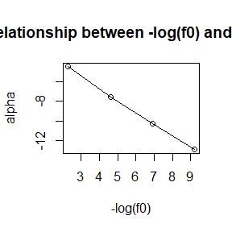

```r
plot(-log(f0_vec), alpha_vec,
     xlab = "-log(f0)",
     ylab = "alpha",
     main = "Relationship between -log(f0) and alpha")
lines(-log(f0_vec), alpha_vec)   # 把四个点连成线，方便看趋势
```

通过模拟可以看到，当我们把目标整体概率 f0从 0.1 调到 0.0001 时，为了维持同样的协变量分布，logit 模型的截距 $\alpha$ 会基本变得越来越负。

# HW8

## Question

Refer to the Bayesian prediction application in Example 11.3, with the Geometric(p) survival model. Prove that the derived parameter$\psi(p)=\frac{p}{1-p}$does not depend on attained age of the individual in this model. (This is not true in general for other models.)

## Answer 11.4

设随机变量 $T$ 为某个体的总寿命（以离散时间度量，$T=0,1,2,\dots$）。 在几何生存模型下，
$$\Pr(T = k) = p^{k}(1-p), \qquad k = 0,1,2,\dots$$
其中 $p$ 为每一时间段存活的概率。例 11.3 已经给出
$$\mathbb{E}[T] = \frac{p}{1-p}.$$

现在考虑已知该个体已经存活到第 $a$ 个时间段的情形，即事件 $\{T \ge a\}$。 定义在此条件下的剩余寿命为
$$R_a = T - a \quad \text{(在条件 $T \ge a$ 下)}.$$
我们要证明：$R_a$ 的期望
$$\mathbb{E}[R_a] = \frac{p}{1-p}$$
与 $a$ 无关，从而派生参数
$$\psi(p) = \frac{p}{1-p}$$
不依赖于个体的已存活年龄 $a$。

首先计算 $R_a$ 的条件分布。对任意 $r=0,1,2,\dots$，有
$$\Pr(R_a = r \mid T \ge a)
= \Pr(T = a+r \mid T \ge a)
= \frac{\Pr(T = a+r)}{\Pr(T \ge a)}.$$
分子为
$$\Pr(T = a+r) = p^{a+r}(1-p).$$
分母为
$$\Pr(T \ge a)
= \sum_{k=a}^{\infty} \Pr(T = k)
= \sum_{k=a}^{\infty} p^{k}(1-p)
= (1-p)\sum_{k=a}^{\infty} p^{k}
= (1-p)\,p^{a}\sum_{j=0}^{\infty} p^{j}
= (1-p)\,p^{a}\cdot\frac{1}{1-p}
= p^{a}.$$
于是
$$\Pr(R_a = r \mid T \ge a)
= \frac{p^{a+r}(1-p)}{p^{a}}
= p^{r}(1-p), \qquad r=0,1,2,\dots$$
这正是几何分布 $\mathrm{Geom}(p)$ 的概率质量函数，且显然不含 $a$。 因此，在条件 $T \ge a$ 下，剩余寿命 $R_a$ 与原始寿命 $T$ 具有相同的几何$(p)$ 分布。

由此可得
$$\mathbb{E}[R_a]
= \mathbb{E}[T]
= \frac{p}{1-p},$$
完全与 $a$ 无关。于是，在几何生存模型下，期望剩余寿命这一派生参数
$$\psi(p) = \frac{p}{1-p}$$
不依赖于个体的已存活年龄（attained age），证毕。

## Question

Use the simplex algorithm to solve the following problem: Minimize 4x + 2y + 9z subject to2x + y + z ≤ 2, x − y + 3z ≤ 3, x ≥ 0, y ≥ 0, z ≥ 0.

## Answer 14.1

```r
# 安装并加载 lpSolve 包
# install.packages("lpSolve")
library(lpSolve)

# 目标函数系数: 4x + 2y + 9z
obj <- c(4, 2, 9)

# 约束矩阵
# 2x + y + z <= 2
# x - y + 3z <= 3
const.mat <- rbind(
  c(2, 1, 1),
  c(1, -1, 3)
)

# 约束方向
const.dir <- c("<=", "<=")

# 右端常数
const.rhs <- c(2, 3)

# 调用单纯形法求“最小化”
res <- lp(direction = "min",
          objective.in = obj,
          const.mat = const.mat,
          const.dir = const.dir,
          const.rhs = const.rhs)

# 输出结果
res$status          # 0 代表求解解
```

```
#> [1] 0
```

## Question

设$X_1,\cdots,X_n\stackrel{\text{i.i.d.}}{\sim}Exp(\lambda)$因为某种原因只知道$X_i$落在区间$(\mu_i,v_i)$其中$\mu_i \lt v_i$ 非随机 (1)试分别直接极大化观测数据的似然函数与采用EM算法求解$\lambda$的MLE.证明EM算法收敛于观测数据的MLE，且收敛有线性速度 (2)设$(\mu_i,v_i),i=1,\dots,n(=10)$的观测值为(11,12),(8,9),(27,28),(13,14),(16,17),(0,1),(23,24),(10,11),(24,25),(2,3)试分别编程实现上述两种算法并比较结果

## Answer

### (1)

设
$$X_1,\dots,X_n\stackrel{\text{i.i.d.}}{\sim}\mathrm{Exp}(\lambda),
\qquad
f(x\mid\lambda)=\lambda e^{-\lambda x},\ x>0,$$
但第 $i$ 个样本只知道 $X_i\in(\mu_i,v_i)$，其中 $\mu_i<v_i$ 为非随机常数。 记 $d_i=v_i-\mu_i>0$。

对单个观测，
$$P(\mu_i<X_i<v_i\mid\lambda)
=F(v_i)-F(\mu_i)
=\bigl(1-e^{-\lambda v_i}\bigr)-\bigl(1-e^{-\lambda\mu_i}\bigr)
=e^{-\lambda\mu_i}-e^{-\lambda v_i}.$$
因此观测数据的似然函数为
$$L(\lambda)
=\prod_{i=1}^n\bigl(e^{-\lambda\mu_i}-e^{-\lambda v_i}\bigr)
=\prod_{i=1}^n e^{-\lambda\mu_i}\bigl(1-e^{-\lambda d_i}\bigr),$$
其对数似然为
$$\ell(\lambda)
=\log L(\lambda)
=\sum_{i=1}^n\left[-\lambda\mu_i+\log\bigl(1-e^{-\lambda
d_i}\bigr)\right].$$

对 $\lambda$ 求一阶导数（得分函数）：
$$\ell'(\lambda)
=\sum_{i=1}^n\left[-\mu_i+\frac{d_i e^{-\lambda d_i}}{1-e^{-\lambda
d_i}}\right]
=\sum_{i=1}^n\left[-\mu_i+\frac{d_i}{e^{\lambda d_i}-1}\right].$$
令 $\ell'(\lambda)=0$ 得到极大似然估计 $\hat\lambda$ 满足
$$\;\sum_{i=1}^n\mu_i
=\sum_{i=1}^n\frac{d_i}{e^{\hat\lambda d_i}-1}\;
\tag{$\ast$}$$
。

二阶导数为
$$\ell''(\lambda)
=\sum_{i=1}^n
\frac{\mathrm{d}}{\mathrm{d}\lambda}
\left(\frac{d_i e^{-\lambda d_i}}{1-e^{-\lambda d_i}}\right)
=\sum_{i=1}^n
\left(-\frac{d_i^2 e^{-\lambda d_i}}{(1-e^{-\lambda
d_i})^2}\right)<0,$$
故 $\ell(\lambda)$ 关于 $\lambda$ 为严格凹函数，得分方程 $(\ast)$ 只有一个根， 该根即为观测数据的唯一 MLE。

把真实的 $X_i$ 视为完整数据，区间 $(\mu_i,v_i)$ 为不完全数据。

为
$$\ell_c(\lambda)
=\sum_{i=1}^n(\log\lambda-\lambda X_i)
=n\log\lambda-\lambda\sum_{i=1}^n X_i.$$

在第 $t$ 次迭代中，参数为 $\lambda^{(t)}$。

计算
$$Q(\lambda\mid\lambda^{(t)})
=\mathbb{E}_{\lambda^{(t)}}\!\bigl[\ell_c(\lambda)\mid
\mu_i<X_i<v_i,\ i=1,\dots,n\bigr]
=n\log\lambda-\lambda\sum_{i=1}^n
\mathbb{E}_{\lambda^{(t)}}\!\bigl[X_i\mid\mu_i<X_i<v_i\bigr].$$

对固定的 $i$，在参数为 $\lambda$ 时
$$f_{X_i\mid\mu_i<X_i<v_i}(x\mid\lambda)
=\frac{\lambda e^{-\lambda x}}
{e^{-\lambda\mu_i}-e^{-\lambda v_i}},
\qquad \mu_i<x<v_i.$$
于是
$$\mathbb{E}(X_i\mid\mu_i<X_i<v_i,\lambda)
=\frac{\displaystyle\int_{\mu_i}^{v_i}x\lambda e^{-\lambda
x}\,\mathrm{d}x}
{e^{-\lambda\mu_i}-e^{-\lambda v_i}}.$$

利用
$$\int x e^{-\lambda x}\,\mathrm{d}x
=-\Bigl(\frac{x}{\lambda}+\frac{1}{\lambda^2}\Bigr)e^{-\lambda x},$$
计算可得
$$\int_{\mu_i}^{v_i}x\lambda e^{-\lambda x}\,\mathrm{d}x
=(\mu_i+\tfrac{1}{\lambda})e^{-\lambda\mu_i}
-(v_i+\tfrac{1}{\lambda})e^{-\lambda v_i}.$$
令 $d_i=v_i-\mu_i$，整理得到
$$\mathbb{E}(X_i\mid\mu_i<X_i<v_i,\lambda)
=\mu_i+\frac{1}{\lambda}
-\frac{d_i e^{-\lambda d_i}}{1-e^{-\lambda d_i}}
=\mu_i+\frac{1}{\lambda}
-\frac{d_i}{e^{\lambda d_i}-1}.$$

因此在 $\lambda^{(t)}$ 下，
$$E_i^{(t)}
:=\mathbb{E}_{\lambda^{(t)}}(X_i\mid\mu_i<X_i<v_i)
=\mu_i+\frac{1}{\lambda^{(t)}}
-\frac{d_i}{e^{\lambda^{(t)} d_i}-1}.$$

$$Q(\lambda\mid\lambda^{(t)})
=n\log\lambda-\lambda\sum_{i=1}^n E_i^{(t)}.$$
对 $\lambda$ 求导并令为零：
$$\frac{\partial Q}{\partial\lambda}
= \frac{n}{\lambda}-\sum_{i=1}^n E_i^{(t)}=0
\quad\Longrightarrow\quad
\lambda^{(t+1)}
=\frac{n}{\sum_{i=1}^n E_i^{(t)}}.$$

将 $E_i^{(t)}$ 的表达式代入，得到 EM 迭代公式
$$\lambda^{(t+1)}=
\left[
\frac{1}{n}\sum_{i=1}^n
\left(
\mu_i+\frac{1}{\lambda^{(t)}}
-\frac{d_i}{e^{\lambda^{(t)} d_i}-1}
\right)
\right]^{-1}.$$

记
$$S(\lambda)
=\sum_{i=1}^n
\mathbb{E}(X_i\mid\mu_i<X_i<v_i,\lambda),
\qquad
M(\lambda)=\frac{n}{S(\lambda)}.$$
则 EM 迭代可写为
$$\lambda^{(t+1)}=M(\lambda^{(t)}).$$

若迭代收敛到极限 $\lambda^\ast$，则必为映射 $M$ 的不动点：
$$\lambda^\ast = M(\lambda^\ast)
\ \Longleftrightarrow\
S(\lambda^\ast)=\frac{n}{\lambda^\ast}.$$
由
$$S(\lambda)
=\sum_{i=1}^n\mu_i+\frac{n}{\lambda}
-\sum_{i=1}^n\frac{d_i}{e^{\lambda d_i}-1},$$
代入 $S(\lambda^\ast)=n/\lambda^\ast$ 得
$$\sum_{i=1}^n\mu_i
=\sum_{i=1}^n\frac{d_i}{e^{\lambda^\ast d_i}-1},$$
这恰好是得分方程 $(\ast)$，因此任何 EM 不动点必为观测数据的 MLE。 由于 $\ell(\lambda)$ 严格凹、MLE 唯一，EM 一旦收敛，就必然收敛到该 MLE。

进一步，关于 EM 的一般理论给出在 MLE $\hat\lambda$ 附近
$$M'(\hat\lambda)
=1-\frac{I_{\mathrm{obs}}(\hat\lambda)}{I_{\mathrm{comp}}(\hat\lambda)},$$
其中 $I_{\mathrm{comp}}(\lambda)=n/\lambda^2$ 是完整数据的 Fisher 信息， $I_{\mathrm{obs}}(\lambda)=-\ell''(\lambda)$ 是观测（区间）数据的 Fisher 信息。 由信息分解
$$I_{\mathrm{comp}}(\lambda)
=I_{\mathrm{obs}}(\lambda)+I_{\mathrm{mis}}(\lambda),
\qquad I_{\mathrm{mis}}(\lambda)>0,$$
可得
$$0<M'(\hat\lambda)
=\frac{I_{\mathrm{mis}}(\hat\lambda)}{I_{\mathrm{comp}}(\hat\lambda)}<1.$$
因此在 $\hat\lambda$ 邻域内，
$$\lambda^{(t+1)}-\hat\lambda
\approx M'(\hat\lambda)\bigl(\lambda^{(t)}-\hat\lambda\bigr),$$
从而 EM 算法以线性速度收敛于观测数据的 MLE。

### (2)

1. 直接极大化观测似然

```r
mu  <- c(11, 8, 27, 13, 16, 0, 23, 10, 24, 2)
v   <- c(12, 9, 28, 14, 17, 1, 24, 11, 25, 3)
d   <- v - mu
n   <- length(mu)

## 对数似然
loglik <- function(lambda) {
  if (lambda <= 0) return(-Inf)
  sum(-lambda * mu + log(1 - exp(-lambda * d)))
}

## 得分函数 \ell'(lambda)
score <- function(lambda) {
  if (lambda <= 0) return(1e10)
  sum(-mu + d * exp(-lambda * d) / (1 - exp(-lambda * d)))
}

## 用 uniroot 解 score(lambda) = 0
fit_direct <- uniroot(score, interval = c(1e-5, 1))
lambda_mle_direct <- fit_direct$root
lambda_mle_direct
```

```
#> [1] 0.07196175
```

```r
loglik(lambda_mle_direct)
```

```
#> [1] -36.31673
```

2. EM 算法实现

```r
EM_exp_interval <- function(lambda0,
                            mu, v,
                            tol = 1e-8,
                            maxit = 1000,
                            trace = TRUE) {
  d <- v - mu
  n <- length(mu)
  lambda <- lambda0
  history <- data.frame(iter = 0,
                        lambda = lambda,
                        loglik = loglik(lambda))

  for (k in 1:maxit) {
    ## E-step: 计算条件期望 E[X_i | mu_i < X_i < v_i, lambda]
    ## 使用简化公式：E = mu + 1/lambda - d/(exp(lambda*d) - 1)
    eX <- mu + 1 / lambda - d / (exp(lambda * d) - 1)
    S  <- sum(eX)

    ## M-step: 更新 lambda
    lambda_new <- n / S

    history <- rbind(history,
                     data.frame(iter = k,
                                lambda = lambda_new,
                                loglik = loglik(lambda_new)))

    if (abs(lambda_new - lambda) < tol) {
      if (trace) print(history)
      return(list(lambda = lambda_new,
                  iter   = k,
                  history = history))
    }
    lambda <- lambda_new
  }
  if (trace) print(history)
  list(lambda = lambda,
       iter   = maxit,
       history = history)
}

## 以几个不同的起始值跑 EM
em1 <- EM_exp_interval(0.2, mu, v)
```

```
#>   iter     lambda    loglik
#> 1    0 0.20000000 -43.87772
#> 2    1 0.07202875 -36.31673
#> 3    2 0.07197352 -36.31673
#> 4    3 0.07197350 -36.31673
#> 5    4 0.07197350 -36.31673
```

```r
em1$lambda        # EM 的极限
```

```
#> [1] 0.0719735
```

```r
em1$iter          # 迭代次数
```

```
#> [1] 4
```

# HW9

## Question

Implement a combination of Map() and vapply() to create an lapply() variant that iterates in parallel over all of its inputs and stores its outputs in a vector (or a matrix). What arguments should the function take?

## Answer

```r
# 定义函数
mvapply <- function(FUN, FUN.VALUE, ...) {
  # 1. 使用 Map 并行迭代所有的输入参数 (...)
  #    Map 会将函数 FUN 应用到 ... 中的每一个元素上，并返回一个列表
  mapped_result <- Map(FUN, ...)

  # 2. 使用 vapply 将 Map 的结果（列表）转换为向量或矩阵
  #    这里使用 identity 函数，因为 mapped_result 已经是计算后的结果了
  #    我们主要利用 vapply 的“简化”和“类型检查”功能
  vapply(mapped_result, identity, FUN.VALUE)
}

# --- 测试案例 1：输出为向量 ---
# 目标：计算两个向量对应元素的和
x <- c(1, 2, 3)
y <- c(10, 20, 30)

# 使用我们定义的 mvapply
# FUN = sum (或 `+`)
# FUN.VALUE = numeric(1) (期望每次计算返回一个数字)
result_vector <- mvapply(sum, numeric(1), x, y)

print("向量输出测试：")
```

```
#> [1] "向量输出测试："
```

```r
print(result_vector)
```

```
#> [1] 11 22 33
```

```r
# 预期输出: 11 22 33


# --- 测试案例 2：输出为矩阵 ---
# 目标：将两个字符向量拼接，并重复两次，形成矩阵
first <- c("A", "B")
last <- c("1", "2")

my_func <- function(a, b) {
  c(paste0(a, b), paste0(b, a))
}

# FUN.VALUE = character(2) (期望每次计算返回长度为2的字符向量)
result_matrix <- mvapply(my_func, character(2), first, last)

print("矩阵输出测试：")
```

```
#> [1] "矩阵输出测试："
```

```r
print(result_matrix)
```

```
#>      A    B
#> [1,] "A1" "B2"
#> [2,] "1A" "2B"
```

```r
# 预期输出: 2x2 矩阵
```

根据上面的实现，该函数应该接受以下三个主要参数： FUN: 要应用的函数。 FUN.VALUE: 这是 vapply 核心所需的参数。它是一个模板向量，用于告诉 R 函数返回值的类型（如 numeric(1)，character(1)）和形状。如果 FUN.VALUE 的长度大于 1，结果将是一个矩阵。 …: 任意数量的输入向量或列表。Map 会并行地在这些输入上进行迭代。

## Question

Make a faster version of chisq.test() that only computes the chi-square test statistic when the input is two numeric vectors with no missing values. You can try simplifying chisq.test() or by coding from the mathematical definition (http://en. wikipedia.org/wiki/Pearson%27s_chi-squared_test).

## Answer

```r
set.seed(1)
# 定义快速卡方检验函数
fast_chisq_test <- function(x, y) {
  # 1. 既然输入是两个向量，首先需要将其转换为列联表（Observed counts）
  #    注意：如果向量包含大量的唯一整数，table() 可能是性能瓶颈，
  #    但对于一般分类数据，这是必须的步骤。
  observed <- table(x, y)

  # 2. 检查是否有全零的行或列（可选，但在数学计算中为了避免除以0是必要的，
  #    不过题目假设无缺失值且隐含数据有效，为了极致速度可以略过，这里保留基本逻辑）
  #    但在极简版本中，我们假设数据是良好的。

  # 3. 计算期望值 (Expected counts)
  #    公式：E = (RowSums * ColSums) / Total
  nr <- nrow(observed)
  nc <- ncol(observed)
  sr <- rowSums(observed)
  sc <- colSums(observed)
  n  <- sum(observed)

  # 使用 outer 函数计算外积矩阵，比循环快
  expected <- outer(sr, sc, "*") / n

  # 4. 计算卡方统计量
  #    公式：sum((O - E)^2 / E)
  #    注意：这里我们不进行 Yates 连续性修正，直接计算皮尔逊卡方
  statistic <- sum((observed - expected)^2 / expected)

  return(statistic)
}

# --- 验证与测试 ---

# 1. 生成测试数据
set.seed(123)
vec1 <- sample(1:3, 1000, replace = TRUE)
vec2 <- sample(1:3, 1000, replace = TRUE)

# 2. 运行我们的快速函数
my_result <- fast_chisq_test(vec1, vec2)
print(paste("快速版本结果:", my_result))
```

```
#> [1] "快速版本结果: 1.73006156307306"
```

```r
# 3. 运行 R 自带函数进行对比
#    注意：chisq.test 默认对 2x2 表格做 Yates 修正，对大表格不做。
#    为了确保一致，我们将 correct 设为 FALSE
std_result <- chisq.test(vec1, vec2, correct = FALSE)$statistic
print(paste("标准版本结果:", std_result))
```

```
#> [1] "标准版本结果: 1.73006156307306"
```

```r
# 检查两者是否相等
print(paste("结果是否一致:", all.equal(my_result, as.numeric(std_result))))
```

```
#> [1] "结果是否一致: TRUE"
```

```r
library(microbenchmark)

microbenchmark(
  original = chisq.test(vec1, vec2, correct = FALSE)$statistic,
  optimized = fast_chisq_test(vec1, vec2),
  times = 100
)
```

```
#> Unit: microseconds
#>       expr   min     lq    mean median    uq    max neval
#>   original 154.6 158.35 163.535 160.65 165.6  234.6   100
#>  optimized 105.0 109.90 153.195 113.55 117.6 3931.9   100
```

## Question

Can you make a faster version of table() for the case of an input of two integer vectors with no missing values? Can you use it to speed up your chi-square test?

## Answer

```r
set.seed(1)
fast_table <- function(x, y) {
  # 1. 获取唯一值并排序，确定矩阵维度
  #    注意：虽然 match 和 unique 有开销，但比 factor() 转换要快。
  #    如果已知输入就是 1:N 的整数，甚至可以跳过这一步直接用 max(x)。
  x_unique <- sort(unique(x))
  y_unique <- sort(unique(y))

  nx <- length(x_unique)
  ny <- length(y_unique)

  # 2. 将 x 和 y 映射为 1 到 N 的整数索引
  #    这是为了防止输入是很稀疏的整数（如 c(1, 10000)），导致分配过大的内存
  xi <- match(x, x_unique)
  yi <- match(y, y_unique)

  # 3. 计算一维扁平索引 (Flattened Index)
  #    这就好比把矩阵一列一列地接起来变成一条长向量
  #    公式：(列号 - 1) * 总行数 + 行号
  index <- (yi - 1) * nx + xi

  # 4. 使用 tabulate 进行底层快速计数
  counts <- tabulate(index, nbins = nx * ny)

  # 5. 将结果重塑为矩阵
  matrix(counts, nrow = nx, ncol = ny)
}
super_fast_chisq <- function(x, y) {
  # --- 优化点：使用我们自定义的 fast_table ---
  observed <- fast_table(x, y)

  # 下面的逻辑与上一题保持一致
  nr <- nrow(observed)
  nc <- ncol(observed)
  sr <- rowSums(observed)
  sc <- colSums(observed)
  n  <- sum(observed)

  expected <- outer(sr, sc, "*") / n

  # 避免除以0的潜在警告（虽然题目假设无缺失且有效，这里稍微稳健一点）
  # 在极速版中通常不加这个检查，或者假设 expected > 0
  sum((observed - expected)^2 / expected)
}
# --- 数据生成 ---
set.seed(42)
# 生成较大的样本以突显性能差异
n_obs <- 1e5
x_vec <- sample(1:5, n_obs, replace = TRUE)
y_vec <- sample(1:5, n_obs, replace = TRUE)

# --- 正确性检查 ---
res_base <- chisq.test(x_vec, y_vec, correct = FALSE)$statistic
res_fast <- super_fast_chisq(x_vec, y_vec)

print(paste("结果差异:", abs(res_base - res_fast))) # 应该接近 0
```

```
#> [1] "结果差异: 0"
```

```r
# --- 性能测试 (使用 microbenchmark 或 system.time) ---
library(microbenchmark)

microbenchmark(
  base_chisq = chisq.test(x_vec, y_vec, correct = FALSE),
  fast_table_chisq = super_fast_chisq(x_vec, y_vec),
  times = 50
)
```

```
#> Unit: milliseconds
#>              expr    min     lq     mean  median     uq     max neval
#>        base_chisq 4.4846 5.8290 7.039782 5.94725 6.1173 17.2694    50
#>  fast_table_chisq 1.9434 2.3664 2.919422 2.45700 2.5501 10.9311    50
```

# HW10

## Question

Rao [232, Sec. 5g] presented an example on genetic linkage of 197 animals in four categories (also discussed in [70, 110, 179, 280]). The group sizes are (125, 18, 20, 34). Assume that the probabilities of the corresponding multinomial distribution are $\left( \frac{1}{2} + \frac{\theta}{4}, \frac{1-\theta}{4}, \frac{1-\theta}{4}, \frac{\theta}{4} \right)$Estimate the posterior distribution of θ given the observed sample, using one of the methods in this chapter.

## Answer

```r
# Check and install necessary packages
if (!require("Rcpp")) install.packages("Rcpp")
```

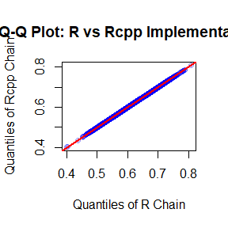

```r
if (!require("microbenchmark")) install.packages("microbenchmark")


library(microbenchmark)



# 数据准备 (Rao's example)
y_obs <- c(125, 18, 20, 34)
n_iter <- 10000
start_val <- 0.5


gibbs_sampler_r <- function(n_iter, y, start_theta) {
  y1 <- y[1]; y2 <- y[2]; y3 <- y[3]; y4 <- y[4]
  theta_chain <- numeric(n_iter)
  theta <- start_theta
  a <- 1.0; b <- 1.0

  for(i in 1:n_iter) {
    # Step 1: Data Augmentation (Update x2)
    # 计算二项分布的概率 prob
    prob_x2 <- theta / (2.0 + theta)
    # 生成 x2
    x2 <- rbinom(1, size = y1, prob = prob_x2)

    # Step 2: Parameter Update (Update theta)
    # 计算 Beta 分布的参数
    shape1 <- x2 + y4 + a
    shape2 <- y2 + y3 + b
    # 生成 theta
    theta <- rbeta(1, shape1, shape2)

    theta_chain[i] <- theta
  }
  return(theta_chain)
}



set.seed(123)
# 运行 R 版本
chain_r <- gibbs_sampler_r(n_iter, y_obs, start_val)

set.seed(123)
# 运行 C++ 版本
chain_cpp <- gibbs_sampler_cpp(n_iter, y_obs, start_val)

# 去除 Burn-in (前1000次迭代)
burn_in <- 1000
clean_r <- chain_r[-(1:burn_in)]
clean_cpp <- chain_cpp[-(1:burn_in)]

# 绘制 Q-Q 图
qqplot(clean_r, clean_cpp,
       main = "Q-Q Plot: R vs Rcpp Implementation",
       xlab = "Quantiles of R Chain",
       ylab = "Quantiles of Rcpp Chain",
       col = rgb(0, 0, 1, 0.2), pch = 19)

# 添加 45度 参考线 (y=x)
abline(0, 1, col = "red", lwd = 2)
```

```r
# 比较运行 1000 次迭代所需的时间
# times = 100 表示每个函数重复运行 100 次取平均
mb_res <- microbenchmark(
  R_Version = gibbs_sampler_r(1000, y_obs, start_val),
  Cpp_Version = gibbs_sampler_cpp(1000, y_obs, start_val),
  times = 100
)

print(mb_res)
```

```
#> Unit: microseconds
#>         expr    min      lq     mean median      uq    max neval
#>    R_Version 1789.0 1818.65 2033.263 1826.9 1851.10 5650.4   100
#>  Cpp_Version  215.2  218.75  221.186  220.0  222.05  256.5   100
```

由qq图可以看出R 和 C++ 代码生成的分布是一致的，从Microbenchmark可以看出C++ 版本的时间远小于 R 版本。